# Deep learning enables accurate clustering with batch effect removal in single-cell RNA-seq analysis

Figures related to the human monocyte dataset

Xiangjie Li, Kui Wang, Yafei Lyu, Huize Pan, Jingxiao Zhang, Dwight Stambolian, Katalin Susztak, Muredach P. Reilly, Gang Hu, Mingyao Li

03/10/2020

[Go back to desc homepage](https://eleozzr.github.io/desc/)

# Data Summary

This dataset was generated by our group, which can be downloaded from [GEO (GSE146974)](https://www.ncbi.nlm.nih.gov/geo/query/acc.cgi?acc=GSE146974). This dataset was generated from human peripheral blood mononuclear clear cells by Ficoll Separation followed by CD14 and CD16 positive cell selection. Since the CD14 and CD16 antibodies are not 100% specific, some T cells were also present in the scRNA-seq data. We performed clustering analysis using Louvain’s algorithm for each batch and identified 288 T cells in total based on the T cell marker genes CD3D, CD3E and CD3G. Aftering removing these 288 T cells, there are 10,878 cells and 21,289 genes, which was processed and sequenced at three different days, resulting in three batches (3,640 cells in T1, 4,833 cells in T2 and 2,405 cells in T3) left in the remaining analysis. Figs. 7- 8 and Supplementary Figs. 14 and 15 show the results for analysis of these data.

*Human monocyte preparation*: Monocyte preparation uses a modification of published protocols. Briefly, ~20 ml blood drawn in sodium heparin was processed immediately in the lab in the Clinical Research Center at Columbia University. PBMCs were isolated by gradient Ficoll paque centrifugation, which maintains cell viability and prevents ex vivo activation during cell recovery. Cells were stained with antibodies against human HLADR, CD14 and CD16 and monocyte subsets defined as HLADR+CD14++CD16-(classical), HLADR+CD14++CD16+ (intermediate), HLADR+CD14dim/CD16++ (nonclassical, patrolling monocyte). DAPI staining was used to exclude dead cells. Monocytes were sorted by a BD Influx Sorter into tubes for real-time 10x Genomics analysis.

```r
options(warn=-1) # turn off warning message globally
.libPaths(c("/home/xiaoxiang/R/x86_64-pc-linux-gnu-library/3.5",.libPaths()))
Sys.setenv(RETICULATE_PYTHON_ENV="/home/xiaoxiang/anaconda3/envs/py36")#="/home/xiaoxiang/.conda/envs/DESCVIR"
#RETICULATE_PYTHON="/home/xiaoxiang/anaconda3/bin/python3",
if ("Seurat" %in% loadedNamespaces()) detach("package:Seurat",unload = T)
suppressPackageStartupMessages(library(reticulate))
suppressPackageStartupMessages(library(devtools))
dyn.load("/home/xiaoxiang/R/x86_64-pc-linux-gnu-library/3.5/sf/libs/sf.so")
suppressPackageStartupMessages(library(monocle,lib.loc = "/usr/lib/R/monocle_alpha"))# devtools::install_github("")
#devtools::install_github("cole-trapnell-lab/DDRTree", ref="simple-ppt-like",lib="/usr/lib/R/monocle_alpha")
#devtools::install_github("r-spatial/sf") if
suppressPackageStartupMessages(library(flexclust))
suppressPackageStartupMessages(library(mcclust))
suppressPackageStartupMessages(library(dplyr))
suppressPackageStartupMessages(library(ggjoy))
suppressPackageStartupMessages(library(VGAM))
suppressPackageStartupMessages(library(knitr))
suppressPackageStartupMessages(library(kableExtra))
#py_install('umap-learn', pip = T, pip_ignore_installed = T)
#import("louvain")
fig_path="/home/xiaoxiang/Documents/DESC_paper_prepare/DESC_paper_final/formal_revised/figures_sep/"
datadirpath="./"
```

```r
df_pseudotime_list=list()
```

```r
get_p_new=function(x) sapply(x,function(i0) ifelse(i0<=0,"<2.2e-16",scales::scientific(i0,digits = 3)))
Stable5=data.frame(Method=c("raw+monocle3","DESC+monocle3","Seurat3.0+monocle3","CCA+monocle3","MNN+monocle3","scVI+monocle3","BERMUDA+monocle3","scanorama+monocle3"),
                  `T1 v.s. T2`=rep("<2.2e-16",length=8),
                  `T1 v.s. T3`=rep("<2.2e-16",length=8),
                  `T2 v.s. T3`=rep("<2.2e-16",length=8),stringsAsFactors = F)
rownames(Stable5)=Stable5$Method
#table5 %>%
#  kable() %>%
#  kable_styling()
```

```r
# load necessay
source("/media/xiaoxiang/D/DESC_reproducible_file/helpfunc_new.R")
#source("/media/xiaoxiang/D/Upenn_computer_backup/Documents/Human_Heart_Project/heart/Heart_result_updated/helpfunc_new.R")
old=theme_set(theme_bw()+theme(strip.background = element_rect(fill="white"),
                                         panel.background = element_blank(),
                                         panel.grid =element_blank()))
```

```r
KL_list=list()
```

```r
resolution_use="0.7"
desc_use=paste0("desc_",resolution_use)
tsne_use=paste0("tsne",resolution_use)
obsm_use=paste0("X_Embeded_z",resolution_use)
```

```r
#dataset="desc_onlyMPH001_resultdataset_label_128_top1000"
dataset="onlyMPH001new/desc_result"
filename=paste0("/media/xiaoxiang/D/raw_data/DECv.1/monocyte_result/",dataset,"/adata_desc.h5ad")
Sys.setenv(RETICULATE_PYTHON="/usr/bin/python3")
ad=import("anndata",convert = FALSE)
adata=ad$read_h5ad(filename)
adata=change_obs(adata,exclude=c("n_genes","n_counts"))# colum
obj0=Convert_from_anndata_to_seurat(adata,raw.X.slot = "count.data")
obj0=NormalizeData(obj0,display.progress = F)
df_desc=getplotdata(adata,reduction.use = tsne_use)
```

```r
raw.data=obj0@raw.data
maprules=c("2017_0801"="T1","2017_1017"="T2","2017_1120"="T3")
#obj0@meta.data$dataset_batch=plyr::maply(obj0@meta.data$batch_label,names(maprules),maprules)
```

# Compared methods

## Monocle3 using raw data

```r
cell.meta.data=obj0@meta.data
cell.meta.data$dataset_batch=plyr::mapvalues(cell.meta.data$batch_label,names(maprules),maprules)
gene_ann=data.frame(gene_short_name = make.unique(rownames(raw.data)),row.names = make.unique(rownames(raw.data)))
pd <- new("AnnotatedDataFrame",data=cell.meta.data)
fd <- new("AnnotatedDataFrame",data=gene_ann)
cds <- newCellDataSet(raw.data, phenoData = pd,featureData =fd,
                          expressionFamily = negbinomial.size(),
                          lowerDetectionLimit=1)

options(DelayedArray.block.size=1000e6)
cds <- estimateSizeFactors(cds)
cds <- estimateDispersions(cds)
```

```
## Removing 12 outliers
```

```r
disp_table = dispersionTable(cds)
disp_table = disp_table %>% mutate(excess_disp =
  (dispersion_empirical - dispersion_fit) / dispersion_fit) %>%
    arrange(plyr::desc(excess_disp))
top_subset_genes = as.character(head(disp_table, 2500)$gene_id)
cds = setOrderingFilter(cds, top_subset_genes)
cds <- preprocessCDS(cds,  method = 'PCA',
                         norm_method = 'log',
                         num_dim = 50,
                         verbose = T)
```

```
## Remove noise by PCA ...
```

```r
df_ori=pData(cds)
ori_dim_use=cds@normalized_data_projection[,1:50]

cds <- reduceDimension(cds, max_components = 2,
                       reduction_method = 'UMAP',
                       metric="correlation",
                       min_dist = 0.75,
                       n_neighbors = 50,
                       verbose = F)
#will give the following
#Retrieving normalized data ...
#Running Uniform Manifold Approximation and Projection
#Python '/usr/bin/python' was requested but '/home/xiaoxiang/anaconda3/envs/py36/bin/python' was loaded instead (see reticulate::py_config() for more information)
cds <- clusterCells(cds, use_pca=T,
                    method = 'louvain',
                    res = 1e-3,
                    louvain_iter = 1,
                    verbose = F)
```

```r
KL_list$raw=BatchKL(df_ori,ori_dim_use,n_cells=100,batch="batch_label")
```

```r
cds <- partitionCells(cds)
cds <- learnGraph(cds,  RGE_method = 'SimplePPT')
#plot_cell_trajectory(cds,color_by = "Cluster")
# a helper function to identify the root principal points:
get_correct_root_state <- function(cds, cell_phenotype, root_type){
  cell_ids <- which(pData(cds)[, cell_phenotype] == root_type)

  closest_vertex <-
    cds@auxOrderingData[[cds@rge_method]]$pr_graph_cell_proj_closest_vertex
  closest_vertex <- as.matrix(closest_vertex[colnames(cds), ])
  root_pr_nodes <-
    V(cds@minSpanningTree)$name[as.numeric(names
      (which.max(table(closest_vertex[cell_ids,]))))]

  root_pr_nodes
}
MPP_node_ids = get_correct_root_state(cds,cell_phenotype ='Cluster', "3")
cds <- orderCells(cds, root_pr_nodes = MPP_node_ids)
#plot_cell_trajectory(cds,color_by = "Cluster")
```

```r
df_den=pData(cds)[,c("Pseudotime","dataset_batch")]
df_den=df_den[!is.infinite(df_den$Pseudotime),]
set.seed(10)

theme_use=theme(legend.text = element_text(size=16),
                legend.title = element_text(size=20))

p_ori_1=plot_cell_trajectory(cds,color_by = "dataset_batch",cell_link_size=0,alpha=0.7,cell_size = 0.2)+
            guides(colour = guide_legend(override.aes = list(alpha=0.7, size=5)))+theme_use

p_ori_2=plot_cell_trajectory(cds,show_branch_points=T,cell_link_size=2,alpha=0.8,cell_size = 0.2)+
            theme(legend.position = "top",
              legend.title = element_text(vjust = 0.2),
              legend.text = element_text(angle=-50 ),
                  legend.key.height = unit(0.5,"cm"),
                  legend.key.width = unit(1,"cm"))+
            guides(color = guide_colourbar(label.position = "top"))+theme_use

p_ori_3=ggplot(data=df_den)+geom_density(aes(x=Pseudotime,fill=dataset_batch),alpha=0.7)+
            scale_y_continuous(expand = c(0,0))+
            scale_x_continuous(expand = c(0,0))+
            theme(legend.position="top")+theme_use

p_monocle_ori=egg::ggarrange(p_ori_1,p_ori_2,p_ori_3,ncol=3,draw=F)
```

```r
# how many cells with no pseudotime
table(is.infinite(pData(cds)[,c("Pseudotime")]))
```

```
##
## FALSE
## 10878
```

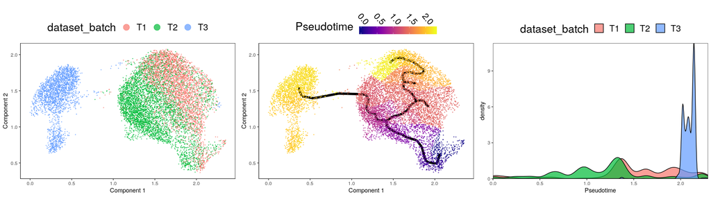

```r
p_monocle_ori
```

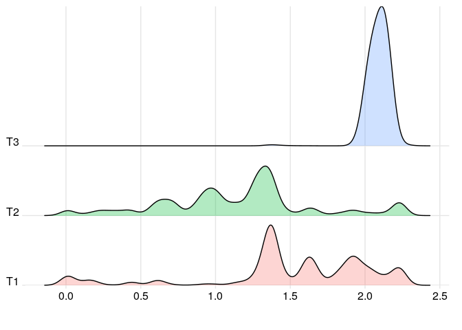

```r
ggplot(df_den, aes(x=Pseudotime, y=dataset_batch,fill=dataset_batch)) +
         ggjoy::geom_joy(scale=2,alpha=0.3) +
         scale_y_discrete(expand = c(0.001, 0))+
         xlab('') +
         #scale_x_continuous(limits = c(0,max(df_den$Pseudotime)))+
         theme_joy() +
         theme(axis.title.y = element_blank())+theme(legend.position = "none")
```

```r
tt1=ks.test(df_den$Pseudotime[df_den$dataset_batch=="T1"],df_den$Pseudotime[df_den$dataset_batch=="T3"])
tt1
```

```
##
##  Two-sample Kolmogorov-Smirnov test
##
## data:  df_den$Pseudotime[df_den$dataset_batch == "T1"] and df_den$Pseudotime[df_den$dataset_batch == "T3"]
## D = 0.83192, p-value < 2.2e-16
## alternative hypothesis: two-sided
```

```r
tt2=ks.test(df_den$Pseudotime[df_den$dataset_batch=="T1"],df_den$Pseudotime[df_den$dataset_batch=="T2"])
tt2
```

```
##
##  Two-sample Kolmogorov-Smirnov test
##
## data:  df_den$Pseudotime[df_den$dataset_batch == "T1"] and df_den$Pseudotime[df_den$dataset_batch == "T2"]
## D = 0.5303, p-value < 2.2e-16
## alternative hypothesis: two-sided
```

```r
tt3=ks.test(df_den$Pseudotime[df_den$dataset_batch=="T2"],df_den$Pseudotime[df_den$dataset_batch=="T3"])
tt3
```

```
##
##  Two-sample Kolmogorov-Smirnov test
##
## data:  df_den$Pseudotime[df_den$dataset_batch == "T2"] and df_den$Pseudotime[df_den$dataset_batch == "T3"]
## D = 0.91617, p-value < 2.2e-16
## alternative hypothesis: two-sided
```

```r
Stable5[1,2:4]=matrix(get_p_new(c(tt1$p.value,tt2$p.value,tt3$p.value)),1,3)
```

```r
p_feature_ori=plot_cell_clusters(cds,markers =c("FCGR3A","S100A8"),cell_size = 0.8,alpha=1)+
  scale_colour_gradient(name="",low="grey",high="red")+theme(legend.position = "right",strip.text = element_text(size=20,face="bold"))
```

```
## 'colour', which will replace the existing scale.
```

```r
#p2=plot_cell_clusters(cds,markers =c("CD14","CD163"),cell_size = 0.8,alpha=1)+
#  scale_colour_gradient(name="",low="grey",high="red")+theme(legend.position = "right",strip.text = element_text(size=20,face="bold"))

#ggsave("~/Documents/DESC_paper_prepare/DESC_paper_v3/figures/figure_supp/monocyte_ori_monocle3_feature.tiff",p1,width=12,height = 5,dpi=300,compression="lzw")
#ggsave("~/Documents/DESC_paper_prepare/DESC_paper_v3/figures/figure_supp/monocyte_ori_add_monocle3_feature.tiff",p2,width=12,height = 5,dpi=300,compression="lzw")
```

```r
cds_exprs <-  as.matrix(exprs(cds[c("FCGR3A","S100A8")]))[1:2,]
df0=data.frame(cbind(pseudotime=pData(cds)$Pseudotime,log1p(t(cds_exprs)/sizeFactors(cds))))
df0$BatchID=pData(cds)$dataset_batch
df0=df0[is.finite(df0$pseudotime),]
df0=df0[order(df0$pseudotime,decreasing = F),,drop=F]
df0$x=df0$pseudotime/max(df0$pseudotime)
df_pseudotime_list$raw=df0
```

## Monocle using representation of DESC

```r
cell.meta.data=obj0@meta.data
cell.meta.data$dataset_batch=plyr::mapvalues(cell.meta.data$batch_label,names(maprules),maprules)
gene_ann=data.frame(gene_short_name = make.unique(rownames(raw.data)),row.names = make.unique(rownames(raw.data)))
pd <- new("AnnotatedDataFrame",data=cell.meta.data)
fd <- new("AnnotatedDataFrame",data=gene_ann)
cds <- newCellDataSet(raw.data, phenoData = pd,featureData =fd,
                          expressionFamily = negbinomial.size(),
                          lowerDetectionLimit=1)

options(DelayedArray.block.size=1000e6)
cds <- estimateSizeFactors(cds)
cds <- estimateDispersions(cds)
```

```
## Removing 12 outliers
```

```r
disp_table = dispersionTable(cds)
disp_table = disp_table %>% mutate(excess_disp =
  (dispersion_empirical - dispersion_fit) / dispersion_fit) %>%
    arrange(plyr::desc(excess_disp))
top_subset_genes = as.character(head(disp_table, 2500)$gene_id)
cds = setOrderingFilter(cds, top_subset_genes)
#cds <- preprocessCDS(cds,  method = 'PCA',
#                         norm_method = 'log',
#                         num_dim = 32,
#                         verbose = T)
desc_dim_use=as.matrix(obj0@dr$Embeded_z0.7@cell.embeddings)
colnames(desc_dim_use)=paste0("PC_",1:ncol(desc_dim_use))
rownames(desc_dim_use)=df_desc$cellname
cds@normalized_data_projection=desc_dim_use[match(cell.meta.data$cellname,rownames(desc_dim_use)),]
#replcae PCA
cds <- reduceDimension(cds, max_components = 2,
                       reduction_method = 'UMAP',
                       metric="correlation",
                       min_dist = 0.75,
                       n_neighbors = 50,
                       verbose = F)
cds <- clusterCells(cds, use_pca=T,
                    method = 'louvain',
                    res = 1e-3,
                    louvain_iter = 1,
                    verbose = F)
#plot_cell_clusters(cds,markers = c("S100A8","FCGR3A"),show_group_id = T, cell_size = 0.1)
```

```r
KL_list$DESC=BatchKL(df_desc,desc_dim_use,n_cells=100,batch="batch_label")
```

```r
cds <- partitionCells(cds)
cds <- learnGraph(cds,  RGE_method = 'SimplePPT')
#plot_cell_trajectory(cds,color_by = "Cluster")
# a helper function to identify the root principal points:
get_correct_root_state <- function(cds, cell_phenotype, root_type){
  cell_ids <- which(pData(cds)[, cell_phenotype] == root_type)

  closest_vertex <-
    cds@auxOrderingData[[cds@rge_method]]$pr_graph_cell_proj_closest_vertex
  closest_vertex <- as.matrix(closest_vertex[colnames(cds), ])
  root_pr_nodes <-
    V(cds@minSpanningTree)$name[as.numeric(names
      (which.max(table(closest_vertex[cell_ids,]))))]

  root_pr_nodes
}
MPP_node_ids = get_correct_root_state(cds,cell_phenotype ='Cluster', "1")
cds <- orderCells(cds, root_pr_nodes = MPP_node_ids)
#plot_cell_trajectory(cds,color_by = "Cluster")
```

```r
df_den=pData(cds)[,c("Pseudotime","dataset_batch")]
df_den=df_den[!is.infinite(df_den$Pseudotime),]
set.seed(10)
theme_use=theme(legend.text = element_text(size=16),
                legend.title = element_text(size=20))

p_desc_1=plot_cell_trajectory(cds,color_by = "dataset_batch",cell_link_size=0,alpha=0.7,cell_size = 0.2)+
            guides(colour = guide_legend(override.aes = list(alpha=0.7, size=5)))+theme_use

p_desc_2=plot_cell_trajectory(cds,show_branch_points=T,cell_link_size=2,alpha=0.8,cell_size = 0.2)+
            theme(legend.position = "top",
              legend.title = element_text(vjust = 0.2),
              legend.text = element_text(angle=-50 ),
                  legend.key.height = unit(0.5,"cm"),
                  legend.key.width = unit(1,"cm"))+
            guides(color = guide_colourbar(label.position = "top"))+theme_use

p_desc_3=ggplot(data=df_den)+geom_density(aes(x=Pseudotime,fill=dataset_batch),alpha=0.7)+
            scale_y_continuous(expand = c(0,0))+
            scale_x_continuous(expand = c(0,0))+
            theme(legend.position="top")+theme_use
p_monocle_desc=egg::ggarrange(p_desc_1,p_desc_2,p_desc_3,ncol=3,draw=F)
```

```r
table(is.infinite(pData(cds)[,c("Pseudotime")]))
```

```
##
## FALSE
## 10878
```

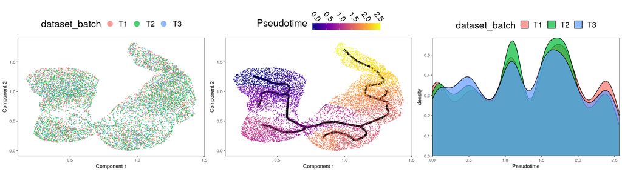

```r
p_monocle_desc
```

```r
#tiff("~/Documents/DESC_paper_prepare/DESC_paper_v3/figures/figure_main/monocyte_monocle_desc.tiff",width=1800*0.8,height=0.8*500)
#p_monocle_desc
#dev.off()
```

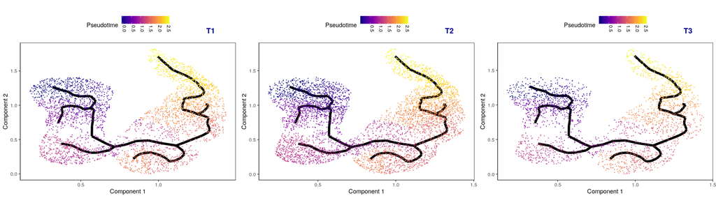

```r
uniquebatch=sort(unique(as.character(pData(cds)$dataset_batch)))
plot_grid(plotlist = lapply(uniquebatch,function(x){
  return(plot_cell_trajectory(cds[,pData(cds)$dataset_batch==x],show_branch_points=T,cell_link_size=2,alpha=0.8,cell_size = 0.2)+ggtitle(x)+
            theme(legend.text = element_text(angle=-90,hjust=1.2,vjust=0),
                  plot.title = element_text(vjust=-15,hjust=0.9,color="darkblue",face="bold"),
                  legend.key.height = unit(0.5,"cm")))}),ncol=3)
```

```r
tt1=ks.test(df_den$Pseudotime[df_den$dataset_batch=="T1"],df_den$Pseudotime[df_den$dataset_batch=="T3"])
tt1
```

```
##
##  Two-sample Kolmogorov-Smirnov test
##
## data:  df_den$Pseudotime[df_den$dataset_batch == "T1"] and df_den$Pseudotime[df_den$dataset_batch == "T3"]
## D = 0.054188, p-value = 0.0004051
## alternative hypothesis: two-sided
```

```r
tt2=ks.test(df_den$Pseudotime[df_den$dataset_batch=="T1"],df_den$Pseudotime[df_den$dataset_batch=="T2"])
tt2
```

```
##
##  Two-sample Kolmogorov-Smirnov test
##
## data:  df_den$Pseudotime[df_den$dataset_batch == "T1"] and df_den$Pseudotime[df_den$dataset_batch == "T2"]
## D = 0.067203, p-value = 1.433e-08
## alternative hypothesis: two-sided
```

```r
tt3=ks.test(df_den$Pseudotime[df_den$dataset_batch=="T2"],df_den$Pseudotime[df_den$dataset_batch=="T3"])
tt3
```

```
##
##  Two-sample Kolmogorov-Smirnov test
##
## data:  df_den$Pseudotime[df_den$dataset_batch == "T2"] and df_den$Pseudotime[df_den$dataset_batch == "T3"]
## D = 0.037531, p-value = 0.02169
## alternative hypothesis: two-sided
```

```r
Stable5[2,2:4]=matrix(get_p_new(c(tt1$p.value,tt2$p.value,tt3$p.value)),1,3)
```

```r
p_feature_desc=plot_cell_clusters(cds,markers =c("FCGR3A","S100A8"),cell_size = 0.8,alpha=1)+
  scale_colour_gradient(name="",low="grey",high="red")+theme(legend.position = "right",strip.text = element_text(size=20,face="bold"))
```

```
## 'colour', which will replace the existing scale.
```

```r
p2=plot_cell_clusters(cds,markers =c("CD14","CD163"),cell_size = 0.8,alpha=1)+
  scale_colour_gradient(name="",low="grey",high="red")+theme(legend.position = "right",strip.text = element_text(size=20,face="bold"))
```

```
## 'colour', which will replace the existing scale.
```

```r
#ggsave("~/Documents/DESC_paper_prepare/DESC_paper_v3/figures/figure_supp/monocyte_desc_monocle3_feature.tiff",p1,width=12,height = 5,dpi=200)
#ggsave("~/Documents/DESC_paper_prepare/DESC_paper_v3/figures/figure_supp/monocyte_desc_add_monocle3_feature.tiff",p2,width=12,height = 5,dpi=200)
```

```r
cds_exprs <-  as.matrix(exprs(cds[c("FCGR3A","S100A8")]))[1:2,]
df0=data.frame(cbind(pseudotime=pData(cds)$Pseudotime,log1p(t(cds_exprs)/sizeFactors(cds))))
df0$BatchID=pData(cds)$dataset_batch
df0=df0[is.finite(df0$pseudotime),]
df0=df0[order(df0$pseudotime,decreasing = F),,drop=F]
df0$x=df0$pseudotime/max(df0$pseudotime)
df_pseudotime_list$desc=df0
```

## Monocle using representation of Seurat3.0

```r
batch_id="dataset_batch"
if ("Seurat" %in% loadedNamespaces()) detach("package:Seurat",unload = T)
suppressPackageStartupMessages(library("Seurat",lib.loc = "/usr/lib/R/self_library/"))
filename=paste0(datadirpath,"/cca3.0_result/","obj_cca3.0_",batch_id,"_2000.rds")
obj=readRDS(filename)
df_cca3.0=cbind(obj[["tsne"]]@cell.embeddings[,c(1,2)],obj@meta.data)
#cca3.0_dim_use=t(obj@assays$integrated@data)
cca3.0_dim_use=obj@reductions$pca@cell.embeddings
raw.data.3.0=obj@assays$RNA@counts
#cca3.0_dim_use=t(obj@assays$integrated@data)
#df0$cca3.0$df_cca3.0=df_cca3.0
#df0$cca3.0$dr_cca3.0=obj[["pca"]]@cell.embeddings[,1:20]
detach("package:Seurat",unload = T)
```

```r
KL_list$Seurat3.0=BatchKL(df_cca3.0,cca3.0_dim_use,n_cells=100,batch="batch_label")
```

```r
cell.meta.data=obj@meta.data
cell.meta.data$dataset_batch=plyr::mapvalues(cell.meta.data$batch_label,names(maprules),maprules)
gene_ann=data.frame(gene_short_name = make.unique(rownames(raw.data.3.0)),row.names = make.unique(rownames(raw.data.3.0)))
                      #make.unique(rownames(obj@assays$RNA@counts)))
pd <- new("AnnotatedDataFrame",data=cell.meta.data)
fd <- new("AnnotatedDataFrame",data=gene_ann)
cds <- newCellDataSet(raw.data.3.0, phenoData = pd,featureData =fd,
                          expressionFamily = negbinomial.size(),
                          lowerDetectionLimit=1)
options(DelayedArray.block.size=1000e6)
cds <- estimateSizeFactors(cds)
cds <- estimateDispersions(cds)
```

```
## Removing 12 outliers
```

```r
disp_table = dispersionTable(cds)
disp_table = disp_table %>% mutate(excess_disp =
  (dispersion_empirical - dispersion_fit) / dispersion_fit) %>%
    arrange(plyr::desc(excess_disp))
top_subset_genes = as.character(head(disp_table, 2500)$gene_id)
cds = setOrderingFilter(cds, top_subset_genes)
#cds <- preprocessCDS(cds,  method = 'PCA',
#                         norm_method = 'log',
#                         num_dim = ncol(cca3.0_dim_use),
#                         verbose = T)
colnames(cca3.0_dim_use)=paste0("PC_",1:ncol(cca3.0_dim_use))

rownames(cca3.0_dim_use)=df_cca3.0$cellname
cds@normalized_data_projection=cca3.0_dim_use[match(cell.meta.data$cellname,rownames(cca3.0_dim_use)),]


cds@normalized_data_projection=cca3.0_dim_use[,1:20] #only top 20 PCs
#replcae PCA
cds <- reduceDimension(cds, max_components = 2,
                       reduction_method = 'UMAP',
                       metric="correlation",
                       min_dist = 0.75,
                       n_neighbors = 50,
                       verbose = F)
cds <- clusterCells(cds, use_pca=T,
                    method = 'louvain',
                    res = 3e-3,
                    louvain_iter = 1,
                    verbose = F)
#plot_cell_clusters(cds,markers = c("S100A8","FCGR3A"),show_group_id = T, cell_size = 0.1)
```

```r
cds <- partitionCells(cds)
cds <- learnGraph(cds,  RGE_method = 'SimplePPT')
#plot_cell_trajectory(cds,color_by = "Cluster")
# a helper function to identify the root principal points:
get_correct_root_state <- function(cds, cell_phenotype, root_type){
  cell_ids <- which(pData(cds)[, cell_phenotype] == root_type)

  closest_vertex <-
    cds@auxOrderingData[[cds@rge_method]]$pr_graph_cell_proj_closest_vertex
  closest_vertex <- as.matrix(closest_vertex[colnames(cds), ])
  root_pr_nodes <-
    V(cds@minSpanningTree)$name[as.numeric(names
      (which.max(table(closest_vertex[cell_ids,]))))]

  root_pr_nodes
}
MPP_node_ids = get_correct_root_state(cds,cell_phenotype ='Cluster', "5")
cds <- orderCells(cds, root_pr_nodes = MPP_node_ids)
#plot_cell_trajectory(cds)
#plot_cell_trajectory(cds,color_by = "Cluster")
```

```r
df_den=pData(cds)[,c("Pseudotime","dataset_batch")]
df_den=df_den[!is.infinite(df_den$Pseudotime),]
set.seed(10)
theme_use=theme(legend.text = element_text(size=16),
                legend.title = element_text(size=20))

p_cca3.0_1=plot_cell_trajectory(cds,color_by = "dataset_batch",cell_link_size=0,alpha=0.7,cell_size = 0.2)+
            guides(colour = guide_legend(override.aes = list(alpha=0.7, size=5)))+theme_use
p_cca3.0_2=plot_cell_trajectory(cds,show_branch_points=T,cell_link_size=2,alpha=0.8,cell_size = 0.2)+
            theme(legend.position = "top",
              legend.title = element_text(vjust = 0.2),
              legend.text = element_text(angle=-50 ),
                  legend.key.height = unit(0.5,"cm"),
                  legend.key.width = unit(1,"cm"))+
            guides(color = guide_colourbar(label.position = "top"))+theme_use
p_cca3.0_3=ggplot(data=df_den)+geom_density(aes(x=Pseudotime,fill=dataset_batch),alpha=0.7)+
            scale_y_continuous(expand = c(0,0))+
            scale_x_continuous(expand = c(0,0))+
            theme(legend.position="top")+theme_use

p_monocle_cca3.0=egg::ggarrange(p_cca3.0_1,p_cca3.0_2,p_cca3.0_3,ncol=3,draw=F)
```

```r
table(is.infinite(pData(cds)[,c("Pseudotime")]))
```

```
##
## FALSE
## 10878
```

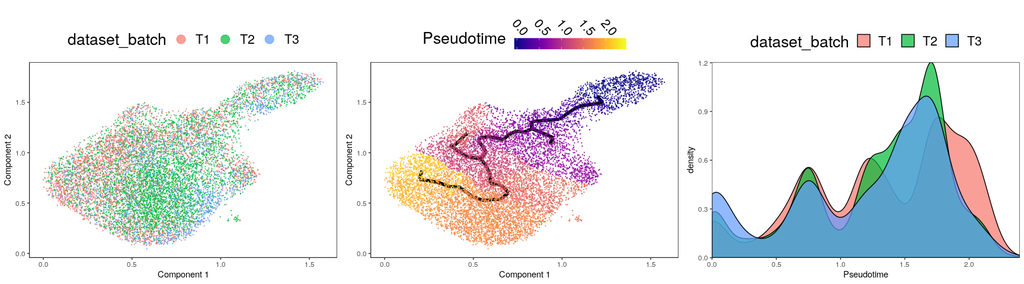

```r
p_monocle_cca3.0
```

```r
#tiff("~/Documents/DESC_paper_prepare/DESC_paper_v3/figures/figure_main/monocyte_monocle_cca3.0.tiff",width=1800*0.8,height=0.8*500)
#p_monocle_cca3.0
#dev.off()
```

```r
tt1=ks.test(df_den$Pseudotime[df_den$dataset_batch=="T1"],df_den$Pseudotime[df_den$dataset_batch=="T3"])
tt1
```

```
##
##  Two-sample Kolmogorov-Smirnov test
##
## data:  df_den$Pseudotime[df_den$dataset_batch == "T1"] and df_den$Pseudotime[df_den$dataset_batch == "T3"]
## D = 0.16822, p-value < 2.2e-16
## alternative hypothesis: two-sided
```

```r
tt2=ks.test(df_den$Pseudotime[df_den$dataset_batch=="T1"],df_den$Pseudotime[df_den$dataset_batch=="T2"])
tt2
```

```
##
##  Two-sample Kolmogorov-Smirnov test
##
## data:  df_den$Pseudotime[df_den$dataset_batch == "T1"] and df_den$Pseudotime[df_den$dataset_batch == "T2"]
## D = 0.16158, p-value < 2.2e-16
## alternative hypothesis: two-sided
```

```r
tt3=ks.test(df_den$Pseudotime[df_den$dataset_batch=="T2"],df_den$Pseudotime[df_den$dataset_batch=="T3"])
tt3
```

```
##
##  Two-sample Kolmogorov-Smirnov test
##
## data:  df_den$Pseudotime[df_den$dataset_batch == "T2"] and df_den$Pseudotime[df_den$dataset_batch == "T3"]
## D = 0.078667, p-value = 4.666e-09
## alternative hypothesis: two-sided
```

```r
Stable5[3,2:4]=matrix(get_p_new(c(tt1$p.value,tt2$p.value,tt3$p.value)),1,3)
```

```r
p_feature_cca3.0=plot_cell_clusters(cds,markers =c("FCGR3A","S100A8"),cell_size = 0.8,alpha=1)+
  scale_colour_gradient(name="",low="grey",high="red")+theme(legend.position = "right",strip.text = element_text(size=20,face="bold"))
```

```
## 'colour', which will replace the existing scale.
```

```r
p2=plot_cell_clusters(cds,markers =c("CD14","CD163"),cell_size = 0.8,alpha=1)+
  scale_colour_gradient(name="",low="grey",high="red")+theme(legend.position = "right",strip.text = element_text(size=20,face="bold"))
```

```
## 'colour', which will replace the existing scale.
```

```r
#ggsave("~/Documents/DESC_paper_prepare/DESC_paper_v3/figures/figure_supp/monocyte_Seurat3.0_monocle3_feature.tiff",p1,width=12,height = 5,dpi=200)
#ggsave("~/Documents/DESC_paper_prepare/DESC_paper_v3/figures/figure_supp/monocyte_Seurat3.0_add_monocle3_feature.tiff",p2,width=12,height = 5,dpi=200)
```

```r
cds_exprs <-  as.matrix(exprs(cds[c("FCGR3A","S100A8")]))[1:2,]
df0=data.frame(cbind(pseudotime=pData(cds)$Pseudotime,log1p(t(cds_exprs)/sizeFactors(cds))))
df0$BatchID=pData(cds)$dataset_batch
df0=df0[is.finite(df0$pseudotime),]
df0=df0[order(df0$pseudotime,decreasing = F),,drop=F]
df0$x=df0$pseudotime/max(df0$pseudotime)
df_pseudotime_list$Seurat3.0=df0
```

```r
if ("Seurat" %in% loadedNamespaces()) detach("package:Seurat",unload = T)
```

## Monocle using representation of CCA

```r
batch_id="dataset_batch"
suppressPackageStartupMessages(library(Seurat))
filename=paste0(datadirpath,"/cca_result/","obj_cca_",batch_id,"_2000_False.rds")
obj=readRDS(filename)
df_cca=cbind(obj@dr$tsne@cell.embeddings[,c(1,2)],obj@meta.data)
#cca3.0_dim_use=t(obj@assays$integrated@data)
cca_dim_use=obj@dr$cca.aligned@cell.embeddings
```

```r
KL_list$CCA=BatchKL(df_cca,cca_dim_use,n_cells=100,batch="batch_label")
```

```r
cell.meta.data=obj@meta.data
cell.meta.data$dataset_batch=plyr::mapvalues(cell.meta.data$batch_label,names(maprules),maprules)
gene_ann=data.frame(gene_short_name = make.unique(rownames(raw.data)),row.names = make.unique(rownames(raw.data)))
pd <- new("AnnotatedDataFrame",data=cell.meta.data)
fd <- new("AnnotatedDataFrame",data=gene_ann)
cds <- newCellDataSet(raw.data,
                      phenoData = pd,
                      featureData =fd,
                          expressionFamily = negbinomial.size(),
                          lowerDetectionLimit=1)
options(DelayedArray.block.size=1000e6)
cds <- estimateSizeFactors(cds)
cds <- estimateDispersions(cds)
```

```
## Removing 12 outliers
```

```r
disp_table = dispersionTable(cds)
disp_table = disp_table %>% mutate(excess_disp =
  (dispersion_empirical - dispersion_fit) / dispersion_fit) %>%
    arrange(plyr::desc(excess_disp))
top_subset_genes = as.character(head(disp_table, 2500)$gene_id)
cds = setOrderingFilter(cds, top_subset_genes)
#cds <- preprocessCDS(cds,  method = 'PCA',
#                         norm_method = 'log',
#                         num_dim = ncol(cca3.0_dim_use),
#                         verbose = T)
colnames(cca_dim_use)=paste0("PC_",1:ncol(cca_dim_use))
rownames(cca_dim_use)=df_cca$cellname
cds@normalized_data_projection=cca_dim_use[match(cell.meta.data$cellname,rownames(cca_dim_use)),]

#replcae PCA
cds <- reduceDimension(cds, max_components = 2,
                       reduction_method = 'UMAP',
                       metric="correlation",
                       min_dist = 0.75,
                       n_neighbors = 50,
                       verbose = F)
cds <- clusterCells(cds, use_pca=T,
                    method = 'louvain',
                    res = 3.5e-3,
                    louvain_iter = 1,
                    verbose = F)
#plot_cell_clusters(cds,markers = c("S100A8","FCGR3A"),show_group_id = T, cell_size = 0.1)
```

```r
cds <- partitionCells(cds)
cds <- learnGraph(cds,  RGE_method = 'SimplePPT')
#plot_cell_trajectory(cds,color_by = "Cluster")
# a helper function to identify the root principal points:
get_correct_root_state <- function(cds, cell_phenotype, root_type){
  cell_ids <- which(pData(cds)[, cell_phenotype] == root_type)

  closest_vertex <-
    cds@auxOrderingData[[cds@rge_method]]$pr_graph_cell_proj_closest_vertex
  closest_vertex <- as.matrix(closest_vertex[colnames(cds), ])
  root_pr_nodes <-
    V(cds@minSpanningTree)$name[as.numeric(names
      (which.max(table(closest_vertex[cell_ids,]))))]

  root_pr_nodes
}
MPP_node_ids = get_correct_root_state(cds,cell_phenotype ='Cluster', "3")
cds <- orderCells(cds, root_pr_nodes = MPP_node_ids)
#plot_cell_trajectory(cds)
#plot_cell_trajectory(cds,color_by = "Cluster")
```

```r
df_den=pData(cds)[,c("Pseudotime","dataset_batch")]
df_den=df_den[!is.infinite(df_den$Pseudotime),]
set.seed(10)
theme_use=theme(legend.text = element_text(size=16),
                legend.title = element_text(size=20))

p_cca_1=plot_cell_trajectory(cds,color_by = "dataset_batch",cell_link_size=0,alpha=0.7,cell_size = 0.2)+
            guides(colour = guide_legend(override.aes = list(alpha=0.7, size=5)))+theme_use
p_cca_2=plot_cell_trajectory(cds,show_branch_points=T,cell_link_size=2,alpha=0.8,cell_size = 0.2)+
            theme(legend.position = "top",
              legend.title = element_text(vjust = 0.2),
              legend.text = element_text(angle=-50 ),
                  legend.key.height = unit(0.5,"cm"),
                  legend.key.width = unit(1,"cm"))+
            guides(color = guide_colourbar(label.position = "top"))+theme_use
p_cca_3=ggplot(data=df_den)+geom_density(aes(x=Pseudotime,fill=dataset_batch),alpha=0.7)+
            scale_y_continuous(expand = c(0,0))+
            scale_x_continuous(expand = c(0,0))+
            theme(legend.position="top")+theme_use
p_monocle_cca=egg::ggarrange(p_cca_1,p_cca_2,p_cca_3,ncol=3,draw = F)
```

```r
table(is.infinite(pData(cds)[,c("Pseudotime")]))
```

```
##
## FALSE
## 10878
```

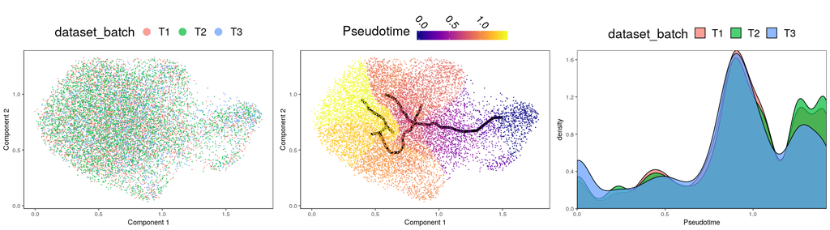

```r
p_monocle_cca
```

```r
tt1=ks.test(df_den$Pseudotime[df_den$dataset_batch=="T1"],df_den$Pseudotime[df_den$dataset_batch=="T3"])
tt1
```

```
##
##  Two-sample Kolmogorov-Smirnov test
##
## data:  df_den$Pseudotime[df_den$dataset_batch == "T1"] and df_den$Pseudotime[df_den$dataset_batch == "T3"]
## D = 0.15916, p-value < 2.2e-16
## alternative hypothesis: two-sided
```

```r
tt2=ks.test(df_den$Pseudotime[df_den$dataset_batch=="T1"],df_den$Pseudotime[df_den$dataset_batch=="T2"])
tt2
```

```
##
##  Two-sample Kolmogorov-Smirnov test
##
## data:  df_den$Pseudotime[df_den$dataset_batch == "T1"] and df_den$Pseudotime[df_den$dataset_batch == "T2"]
## D = 0.099524, p-value < 2.2e-16
## alternative hypothesis: two-sided
```

```r
tt3=ks.test(df_den$Pseudotime[df_den$dataset_batch=="T2"],df_den$Pseudotime[df_den$dataset_batch=="T3"])
tt3
```

```
##
##  Two-sample Kolmogorov-Smirnov test
##
## data:  df_den$Pseudotime[df_den$dataset_batch == "T2"] and df_den$Pseudotime[df_den$dataset_batch == "T3"]
## D = 0.16291, p-value < 2.2e-16
## alternative hypothesis: two-sided
```

```r
Stable5[4,2:4]=matrix(get_p_new(c(tt1$p.value,tt2$p.value,tt3$p.value)),1,3)
```

```r
p_feature_cca=plot_cell_clusters(cds,markers =c("FCGR3A","S100A8"),cell_size = 0.8,alpha=1)+
  scale_colour_gradient(name="",low="grey",high="red")+theme(legend.position = "right",strip.text = element_text(size=20,face="bold"))
```

```
## 'colour', which will replace the existing scale.
```

```r
p2=plot_cell_clusters(cds,markers =c("CD14","CD163"),cell_size = 0.8,alpha=1)+
  scale_colour_gradient(name="",low="grey",high="red")+theme(legend.position = "right",strip.text = element_text(size=20,face="bold"))
```

```
## 'colour', which will replace the existing scale.
```

```r
#ggsave("~/Documents/DESC_paper_prepare/DESC_paper_v3/figures/figure_supp/monocyte_CCA_monocle3_feature.tiff",p1,width=12,height = 5,dpi=200)
#ggsave("~/Documents/DESC_paper_prepare/DESC_paper_v3/figures/figure_supp/monocyte_CCA_add_monocle3_feature.tiff",p2,width=12,height = 5,dpi=200)
```

```r
cds_exprs <-  as.matrix(exprs(cds[c("FCGR3A","S100A8")]))[1:2,]
df0=data.frame(cbind(pseudotime=pData(cds)$Pseudotime,log1p(t(cds_exprs)/sizeFactors(cds))))
df0$BatchID=pData(cds)$dataset_batch
df0=df0[is.finite(df0$pseudotime),]
df0=df0[order(df0$pseudotime,decreasing = F),,drop=F]
df0$x=df0$pseudotime/max(df0$pseudotime)
df_pseudotime_list$CCA=df0
```

```r
if ("Seurat" %in% loadedNamespaces()) detach("package:Seurat",unload = T)
```

## Monocle using representation of MNN

```r
batch_id="dataset_batch"
filename=paste0(datadirpath,"/mnn_result/","adata_mnn_",batch_id,"_2000_False.h5ad")
suppressPackageStartupMessages(library(Seurat))
ad=import("anndata",convert = FALSE)
adata=ad$read_h5ad(filename)
adata=change_obs(adata,exclude=c("n_genes","n_counts","sample"))# colum
#print(mclust::adjustedRandIndex(df_cca$cluster,df_cca$integrated_snn_res.0.2))
mnn_dim_use=py_to_r(adata$obsm["X_pca"])[,c(1:20)]
df_mnn=py_to_r(adata$obs)
id0=match(rownames(df_desc),paste0(df_mnn$cellname,"-",df_mnn$dataset_batch))
mnn_dim_use=mnn_dim_use[id0,]
rownames(mnn_dim_use)=rownames(df_desc)# 因为是match之后的
```

```r
KL_list$MNN=BatchKL(df_mnn,mnn_dim_use,n_cells=100,batch="batch_label")
```

```r
cell.meta.data=obj0@meta.data
cell.meta.data$dataset_batch=plyr::mapvalues(cell.meta.data$batch_label,names(maprules),maprules)
gene_ann=data.frame(gene_short_name = make.unique(rownames(raw.data)),row.names = make.unique(rownames(raw.data)))
pd <- new("AnnotatedDataFrame",data=cell.meta.data)
fd <- new("AnnotatedDataFrame",data=gene_ann)
cds <- newCellDataSet(raw.data, phenoData = pd,featureData =fd,
                          expressionFamily = negbinomial.size(),
                          lowerDetectionLimit=1)
options(DelayedArray.block.size=1000e6)
cds <- estimateSizeFactors(cds)
cds <- estimateDispersions(cds)
```

```
## Removing 12 outliers
```

```r
disp_table = dispersionTable(cds)
disp_table = disp_table %>% mutate(excess_disp =
  (dispersion_empirical - dispersion_fit) / dispersion_fit) %>%
    arrange(plyr::desc(excess_disp))
top_subset_genes = as.character(head(disp_table, 2500)$gene_id)
cds = setOrderingFilter(cds, top_subset_genes)
#cds <- preprocessCDS(cds,  method = 'PCA',
#                         norm_method = 'log',
#                         num_dim = ncol(cca3.0_dim_use),
#                         verbose = T)
colnames(mnn_dim_use)=paste0("PC_",1:ncol(mnn_dim_use))
cds@normalized_data_projection=mnn_dim_use[match(cell.meta.data$cellname,rownames(mnn_dim_use)),]

#replcae PCA
cds <- reduceDimension(cds, max_components = 2,
                       reduction_method = 'UMAP',
                       metric="correlation",
                       min_dist = 0.75,
                       n_neighbors = 50,
                       verbose = F)
cds <- clusterCells(cds, use_pca=T,
                    method = 'louvain',
                    res = 3e-3,
                    louvain_iter = 1,
                    verbose = F)
#plot_cell_clusters(cds,markers = c("S100A8","FCGR3A"),show_group_id = T, cell_size = 0.1)
```

```r
cds <- partitionCells(cds)
cds <- learnGraph(cds,  RGE_method = 'SimplePPT')
#plot_cell_trajectory(cds,color_by = "Cluster")
# a helper function to identify the root principal points:
get_correct_root_state <- function(cds, cell_phenotype, root_type){
  cell_ids <- which(pData(cds)[, cell_phenotype] == root_type)
  closest_vertex <-
    cds@auxOrderingData[[cds@rge_method]]$pr_graph_cell_proj_closest_vertex
  closest_vertex <- as.matrix(closest_vertex[colnames(cds), ])
  root_pr_nodes <-
    V(cds@minSpanningTree)$name[as.numeric(names
      (which.max(table(closest_vertex[cell_ids,]))))]

  root_pr_nodes
}
MPP_node_ids = get_correct_root_state(cds,cell_phenotype ='Cluster', "4")
cds <- orderCells(cds, root_pr_nodes = MPP_node_ids)
#plot_cell_trajectory(cds)
#plot_cell_trajectory(cds,color_by = "Cluster")
```

```r
if ("Seurat" %in% loadedNamespaces()) detach("package:Seurat",unload = T)
```

```r
df_den=pData(cds)[,c("Pseudotime","dataset_batch")]
df_den=df_den[!is.infinite(df_den$Pseudotime),]
set.seed(10)
theme_use=theme(legend.text = element_text(size=16),
                legend.title = element_text(size=20))

p_mnn_1=plot_cell_trajectory(cds,color_by = "dataset_batch",cell_link_size=0,alpha=0.7,cell_size = 0.2)+
            guides(colour = guide_legend(override.aes = list(alpha=0.7, size=5)))+theme_use

p_mnn_2=plot_cell_trajectory(cds,show_branch_points=T,cell_link_size=2,alpha=0.8,cell_size = 0.2)+
            theme(legend.position = "top",
              legend.title = element_text(vjust = 0.2),
              legend.text = element_text(angle=-50 ),
                  legend.key.height = unit(0.5,"cm"),
                  legend.key.width = unit(1,"cm"))+
            guides(color = guide_colourbar(label.position = "top"))+theme_use

p_mnn_3=ggplot(data=df_den)+geom_density(aes(x=Pseudotime,fill=dataset_batch),alpha=0.7)+
            scale_y_continuous(expand = c(0,0))+
            scale_x_continuous(expand = c(0,0))+
            theme(legend.position="top")+theme_use
p_monocle_mnn=egg::ggarrange(p_mnn_1,p_mnn_2,p_mnn_3,ncol=3,draw=F)
```

```r
table(is.infinite(pData(cds)[,c("Pseudotime")]))
```

```
##
## FALSE
## 10878
```

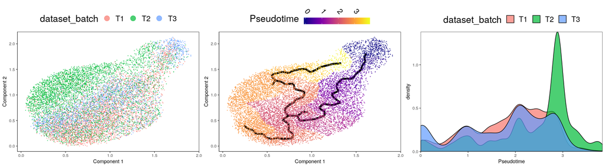

```r
p_monocle_mnn
```

```r
#tiff("~/Documents/DESC_paper_prepare/DESC_paper_v3/figures/figure_main/monocyte_monocle_mnn.tiff",width=1800*0.8,height=0.8*500)
#p_monocle_mnn
#dev.off()
```

```r
tt1=ks.test(df_den$Pseudotime[df_den$dataset_batch=="T1"],df_den$Pseudotime[df_den$dataset_batch=="T3"])
tt1
```

```
##
##  Two-sample Kolmogorov-Smirnov test
##
## data:  df_den$Pseudotime[df_den$dataset_batch == "T1"] and df_den$Pseudotime[df_den$dataset_batch == "T3"]
## D = 0.10442, p-value = 3.864e-14
## alternative hypothesis: two-sided
```

```r
tt2=ks.test(df_den$Pseudotime[df_den$dataset_batch=="T1"],df_den$Pseudotime[df_den$dataset_batch=="T2"])
tt2
```

```
##
##  Two-sample Kolmogorov-Smirnov test
##
## data:  df_den$Pseudotime[df_den$dataset_batch == "T1"] and df_den$Pseudotime[df_den$dataset_batch == "T2"]
## D = 0.38753, p-value < 2.2e-16
## alternative hypothesis: two-sided
```

```r
tt3=ks.test(df_den$Pseudotime[df_den$dataset_batch=="T2"],df_den$Pseudotime[df_den$dataset_batch=="T3"])
tt3
```

```
##
##  Two-sample Kolmogorov-Smirnov test
##
## data:  df_den$Pseudotime[df_den$dataset_batch == "T2"] and df_den$Pseudotime[df_den$dataset_batch == "T3"]
## D = 0.41069, p-value < 2.2e-16
## alternative hypothesis: two-sided
```

```r
Stable5[5,2:4]=matrix(get_p_new(c(tt1$p.value,tt2$p.value,tt3$p.value)),1,3)
```

```r
#tiff("~/Documents/DESC_paper_prepare/DESC_paper_v2/figures/figure_supp/monocyte_MNN_monocle3_feature.tiff",width=1200*0.65,height=0.65*500)
#plot_grid(plot_cell_clusters(cds,markers = "FCGR3A",cell_size = 0.8)+theme_use,
 #         plot_cell_clusters(cds,markers = "S100A8",cell_size = 0.8)+theme_use,ncol=2)
#dev.off()
p_feature_mnn=plot_cell_clusters(cds,markers =c("FCGR3A","S100A8"),cell_size = 0.8,alpha=1)+
  scale_colour_gradient(name="",low="grey",high="red")+theme(legend.position = "right",strip.text = element_text(size=20,face="bold"))
```

```
## 'colour', which will replace the existing scale.
```

```r
p2=plot_cell_clusters(cds,markers =c("CD14","CD163"),cell_size = 0.8,alpha=1)+
  scale_colour_gradient(name="",low="grey",high="red")+theme(legend.position = "right",strip.text = element_text(size=20,face="bold"))
```

```
## 'colour', which will replace the existing scale.
```

```r
#ggsave("~/Documents/DESC_paper_prepare/DESC_paper_v3/figures/figure_supp/monocyte_MNN_monocle3_feature.tiff",p1,width=12,height = 5,dpi=200)
#ggsave("~/Documents/DESC_paper_prepare/DESC_paper_v3/figures/figure_supp/monocyte_MNN_add_monocle3_feature.tiff",p2,width=12,height = 5,dpi=200)
```

```r
cds_exprs <-  as.matrix(exprs(cds[c("FCGR3A","S100A8")]))[1:2,]
df0=data.frame(cbind(pseudotime=pData(cds)$Pseudotime,log1p(t(cds_exprs)/sizeFactors(cds))))
df0$BatchID=pData(cds)$dataset_batch
df0=df0[is.finite(df0$pseudotime),]
df0=df0[order(df0$pseudotime,decreasing = F),,drop=F]
df0$x=df0$pseudotime/max(df0$pseudotime)
df_pseudotime_list$MNN=df0
```

## Monocle using representation of scVI

```r
batch_id="dataset_batch"
filename=paste0(datadirpath,"/scvi_result/","adata_scvi_",batch_id,"_2000_False.h5ad")
ad=import("anndata",convert = FALSE)
adata=ad$read_h5ad(filename)
adata=change_obs(adata,exclude=c("n_genes","n_counts","sample"))# colum
df_scvi=getplotdata(adata,reduction.use = "tsne")
#print(mclust::adjustedRandIndex(df_cca$cluster,df_cca$integrated_snn_res.0.2))
scvi_dim_use=py_to_r(adata$X)
```

```r
KL_list$scVI=BatchKL(df_scvi,scvi_dim_use,n_cells=100,batch="batch_label")
```

```r
cell.meta.data=obj0@meta.data
cell.meta.data$dataset_batch=plyr::mapvalues(cell.meta.data$batch_label,names(maprules),maprules)
gene_ann=data.frame(gene_short_name = make.unique(rownames(raw.data)),row.names = make.unique(rownames(raw.data)))
pd <- new("AnnotatedDataFrame",data=cell.meta.data)
fd <- new("AnnotatedDataFrame",data=gene_ann)
cds <- newCellDataSet(obj0@raw.data, phenoData = pd,featureData =fd,
                          expressionFamily = negbinomial.size(),
                          lowerDetectionLimit=1)
options(DelayedArray.block.size=1000e6)
cds <- estimateSizeFactors(cds)
cds <- estimateDispersions(cds)
```

```
## Removing 12 outliers
```

```r
disp_table = dispersionTable(cds)
disp_table = disp_table %>% mutate(excess_disp =
  (dispersion_empirical - dispersion_fit) / dispersion_fit) %>%
    arrange(plyr::desc(excess_disp))
top_subset_genes = as.character(head(disp_table, 2500)$gene_id)
cds = setOrderingFilter(cds, top_subset_genes)
#cds <- preprocessCDS(cds,  method = 'PCA',
#                         norm_method = 'log',
#                         num_dim = 20,
#                         verbose = T)
colnames(scvi_dim_use)=paste0("PC_",1:ncol(scvi_dim_use))
rownames(scvi_dim_use)=df_scvi$cellname
cds@normalized_data_projection=scvi_dim_use[match(cell.meta.data$cellname,rownames(scvi_dim_use)),]

#replcae PCA
cds <- reduceDimension(cds, max_components = 2,
                       reduction_method = 'UMAP',
                       metric="correlation",
                       min_dist = 0.75,
                       n_neighbors = 50,
                       verbose = F)
cds <- clusterCells(cds, use_pca=T,
                    method = 'louvain',
                    res = 3e-3,
                    louvain_iter = 1,
                    verbose = F)
#plot_cell_clusters(cds,markers = c("S100A8","FCGR3A"),show_group_id = T, cell_size = 0.1)
```

```r
cds <- partitionCells(cds)
cds <- learnGraph(cds,  RGE_method = 'SimplePPT')
get_correct_root_state <- function(cds, cell_phenotype, root_type){
  cell_ids <- which(pData(cds)[, cell_phenotype] == root_type)

  closest_vertex <-
    cds@auxOrderingData[[cds@rge_method]]$pr_graph_cell_proj_closest_vertex
  closest_vertex <- as.matrix(closest_vertex[colnames(cds), ])
  root_pr_nodes <-
    V(cds@minSpanningTree)$name[as.numeric(names
      (which.max(table(closest_vertex[cell_ids,]))))]

  root_pr_nodes
}
MPP_node_ids = get_correct_root_state(cds,cell_phenotype ='Cluster', "5")
cds <- orderCells(cds, root_pr_nodes = MPP_node_ids)
#plot_cell_trajectory(cds)
#plot_cell_trajectory(cds,color_by = "Cluster")
```

```r
df_den=pData(cds)[,c("Pseudotime","dataset_batch")]
df_den=df_den[!is.infinite(df_den$Pseudotime),]
set.seed(10)
theme_use=theme(legend.text = element_text(size=16),
                legend.title = element_text(size=20))

p_scvi_1=plot_cell_trajectory(cds,color_by = "dataset_batch",cell_link_size=0,alpha=0.7,cell_size = 0.2)+
            guides(colour = guide_legend(override.aes = list(alpha=0.7, size=5)))+theme_use

p_scvi_2=plot_cell_trajectory(cds,show_branch_points=T,cell_link_size=2,alpha=0.8,cell_size = 0.2)+
            theme(legend.position = "top",
              legend.title = element_text(vjust = 0.2),
              legend.text = element_text(angle=-50 ),
                  legend.key.height = unit(0.5,"cm"),
                  legend.key.width = unit(1,"cm"))+
            guides(color = guide_colourbar(label.position = "top"))+theme_use

p_scvi_3=ggplot(data=df_den)+geom_density(aes(x=Pseudotime,fill=dataset_batch),alpha=0.7)+
            scale_y_continuous(expand = c(0,0))+
            scale_x_continuous(expand = c(0,0))+
            theme(legend.position="top")+theme_use
p_monocle_scvi=egg::ggarrange(p_scvi_1,p_scvi_2,p_scvi_3,ncol=3,draw=F)
```

```r
table(is.infinite(pData(cds)[,c("Pseudotime")]))
```

```
##
## FALSE
## 10878
```

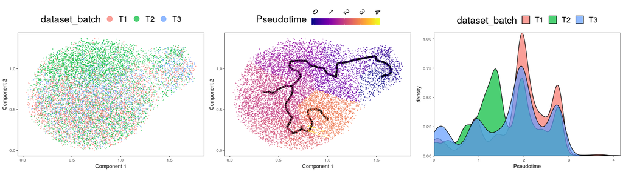

```r
p_monocle_scvi
```

```r
#tiff("~/Documents/DESC_paper_prepare/DESC_paper_v3/figures/figure_main/monocyte_monocle_scvi.tiff",width=1800*0.8,height=0.8*500)
#p_monocle_scvi
#dev.off()
```

```r
tt1=ks.test(df_den$Pseudotime[df_den$dataset_batch=="T1"],df_den$Pseudotime[df_den$dataset_batch=="T3"])
tt1
```

```
##
##  Two-sample Kolmogorov-Smirnov test
##
## data:  df_den$Pseudotime[df_den$dataset_batch == "T1"] and df_den$Pseudotime[df_den$dataset_batch == "T3"]
## D = 0.1548, p-value < 2.2e-16
## alternative hypothesis: two-sided
```

```r
tt2=ks.test(df_den$Pseudotime[df_den$dataset_batch=="T1"],df_den$Pseudotime[df_den$dataset_batch=="T2"])
tt2
```

```
##
##  Two-sample Kolmogorov-Smirnov test
##
## data:  df_den$Pseudotime[df_den$dataset_batch == "T1"] and df_den$Pseudotime[df_den$dataset_batch == "T2"]
## D = 0.29338, p-value < 2.2e-16
## alternative hypothesis: two-sided
```

```r
tt3=ks.test(df_den$Pseudotime[df_den$dataset_batch=="T2"],df_den$Pseudotime[df_den$dataset_batch=="T3"])
tt3
```

```
##
##  Two-sample Kolmogorov-Smirnov test
##
## data:  df_den$Pseudotime[df_den$dataset_batch == "T2"] and df_den$Pseudotime[df_den$dataset_batch == "T3"]
## D = 0.17777, p-value < 2.2e-16
## alternative hypothesis: two-sided
```

```r
Stable5[6,2:4]=matrix(get_p_new(c(tt1$p.value,tt2$p.value,tt3$p.value)),1,3)
```

```r
p_feature_scvi=plot_cell_clusters(cds,markers =c("FCGR3A","S100A8"),cell_size = 0.8,alpha=1)+
  scale_colour_gradient(name="",low="grey",high="red")+theme(legend.position = "right",strip.text = element_text(size=20,face="bold"))
```

```
## 'colour', which will replace the existing scale.
```

```r
p2=plot_cell_clusters(cds,markers =c("CD14","CD163"),cell_size = 0.8,alpha=1)+
  scale_colour_gradient(name="",low="grey",high="red")+theme(legend.position = "right",strip.text = element_text(size=20,face="bold"))
```

```
## 'colour', which will replace the existing scale.
```

```r
#ggsave("~/Documents/DESC_paper_prepare/DESC_paper_v3/figures/figure_supp/monocyte_scVI_monocle3_feature.tiff",p1,width=12,height = 5,dpi=200)
#ggsave("~/Documents/DESC_paper_prepare/DESC_paper_v3/figures/figure_supp/monocyte_scVI_add_monocle3_feature.tiff",p2,width=12,height = 5,dpi=200)
```

```r
cds_exprs <-  as.matrix(exprs(cds[c("FCGR3A","S100A8")]))[1:2,]
df0=data.frame(cbind(pseudotime=pData(cds)$Pseudotime,log1p(t(cds_exprs)/sizeFactors(cds))))
df0$BatchID=pData(cds)$dataset_batch
df0=df0[is.finite(df0$pseudotime),]
df0=df0[order(df0$pseudotime,decreasing = F),,drop=F]
df0$x=df0$pseudotime/max(df0$pseudotime)
df_pseudotime_list$scVI=df0
```

## BERMUDA0.90

```r
filename=paste0(datadirpath,"/BERMUDA_result/adata_bermuda0.9_dataset_batch.h5ad")
ad=import("anndata",convert = FALSE)
adata=ad$read_h5ad(filename)
adata=change_obs(adata,exclude=c("n_genes","n_counts","sample"))# colum
df_bermuda=getplotdata(adata,reduction.use = "tsne")%>%left_join(df_desc[,c("cellname","batch_label","dataset_batch","status_label")],by="cellname")
#print(mclust::adjustedRandIndex(df_cca$cluster,df_cca$integrated_snn_res.0.2))
bermuda_dim_use=py_to_r(adata$obsm[["X_bermuda"]])
```

```r
KL_list$BERMUDA0.90=BatchKL(df_bermuda,bermuda_dim_use,n_cells=100,batch="batch_label")
```

```r
cell.meta.data=obj0@meta.data
cell.meta.data$dataset_batch=plyr::mapvalues(cell.meta.data$batch_label,names(maprules),maprules)
gene_ann=data.frame(gene_short_name = make.unique(rownames(obj0@raw.data)),row.names = make.unique(rownames(obj0@raw.data)))
pd <- new("AnnotatedDataFrame",data=cell.meta.data)
fd <- new("AnnotatedDataFrame",data=gene_ann)
cds <- newCellDataSet(obj0@raw.data, phenoData = pd,featureData =fd,
                      expressionFamily = negbinomial.size(),
                      lowerDetectionLimit=1)
options(DelayedArray.block.size=1000e6)
cds <- estimateSizeFactors(cds)
cds <- estimateDispersions(cds)
```

```
## Removing 12 outliers
```

```r
disp_table = dispersionTable(cds)
disp_table = disp_table %>% mutate(excess_disp =
                                     (dispersion_empirical - dispersion_fit) / dispersion_fit) %>%
  arrange(plyr::desc(excess_disp))
top_subset_genes = as.character(head(disp_table, 2500)$gene_id)
cds = setOrderingFilter(cds, top_subset_genes)
#cds <- preprocessCDS(cds,  method = 'PCA',
#                         norm_method = 'log',
#                         num_dim = 20,
#                         verbose = T)
colnames(bermuda_dim_use)=paste0("PC_",1:ncol(bermuda_dim_use))
rownames(bermuda_dim_use)=df_bermuda$cellname
cds@normalized_data_projection=bermuda_dim_use[match(cell.meta.data$cellname,rownames(bermuda_dim_use)),]
#replcae PCA
cds <- reduceDimension(cds, max_components = 2,
                       reduction_method = 'UMAP',
                       metric="correlation",
                       min_dist = 0.75,
                       n_neighbors = 50,
                       verbose = F)
cds <- clusterCells(cds, use_pca=T,
                    method = 'louvain',
                    res = 3e-3,
                    louvain_iter = 1,
                    verbose = F)
#plot_cell_clusters(cds,markers = c("S100A8","FCGR3A"),show_group_id = T, cell_size = 0.1)
```

```r
cds <- partitionCells(cds)
cds <- learnGraph(cds,  RGE_method = 'SimplePPT')
#plot_cell_trajectory(cds,color_by = "Cluster")
# a helper function to identify the root principal points:
get_correct_root_state <- function(cds, cell_phenotype, root_type){
  cell_ids <- which(pData(cds)[, cell_phenotype] == root_type)

  closest_vertex <-
    cds@auxOrderingData[[cds@rge_method]]$pr_graph_cell_proj_closest_vertex
  closest_vertex <- as.matrix(closest_vertex[colnames(cds), ])
  root_pr_nodes <-
    V(cds@minSpanningTree)$name[as.numeric(names
                                           (which.max(table(closest_vertex[cell_ids,]))))]

  root_pr_nodes
}
MPP_node_ids = get_correct_root_state(cds,cell_phenotype ='Cluster', "4")
cds <- orderCells(cds, root_pr_nodes = MPP_node_ids)
#plot_cell_trajectory(cds,color_by = "Cluster")
```

```r
df_den=pData(cds)[,c("Pseudotime","dataset_batch")]
df_den=df_den[!is.infinite(df_den$Pseudotime),]
set.seed(10)
theme_use=theme(legend.text = element_text(size=16),
                legend.title = element_text(size=20))

p_bermuda_1=plot_cell_trajectory(cds,color_by = "dataset_batch",cell_link_size=0,alpha=0.7,cell_size = 0.2)+
                                   guides(colour = guide_legend(override.aes = list(alpha=0.7, size=5)))+theme_use

p_bermuda_2=plot_cell_trajectory(cds,show_branch_points=T,cell_link_size=2,alpha=0.8,cell_size = 0.2)+
                                   theme(legend.position = "top",
                                         legend.title = element_text(vjust = 0.2),
                                         legend.text = element_text(angle=-50 ),
                                         legend.key.height = unit(0.5,"cm"),
                                         legend.key.width = unit(1,"cm"))+
                                   guides(color = guide_colourbar(label.position = "top"))+theme_use

p_bermuda_3=ggplot(data=df_den)+geom_density(aes(x=Pseudotime,fill=dataset_batch),alpha=0.7)+
                                   scale_y_continuous(expand = c(0,0))+
                                   scale_x_continuous(expand = c(0,0))+
                                   theme(legend.position="top")+theme_use
p_monocle_bermuda0.90=egg::ggarrange(p_bermuda_1,p_bermuda_2,p_bermuda_3,ncol=3,draw=F)
```

```r
table(is.infinite(pData(cds)[,c("Pseudotime")]))
```

```
##
## FALSE  TRUE
## 10825    53
```

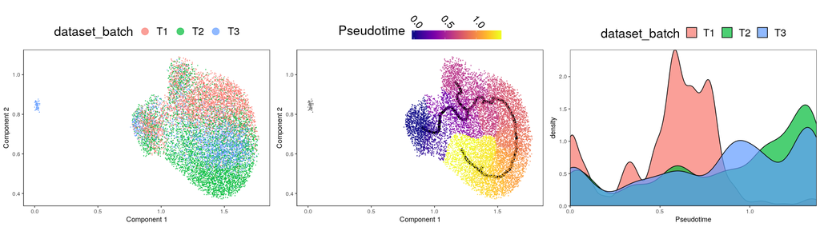

```r
p_monocle_bermuda0.90
```

```r
tt1=ks.test(df_den$Pseudotime[df_den$dataset_batch=="T1"],df_den$Pseudotime[df_den$dataset_batch=="T3"])
tt1
```

```
##
##  Two-sample Kolmogorov-Smirnov test
##
## data:  df_den$Pseudotime[df_den$dataset_batch == "T1"] and df_den$Pseudotime[df_den$dataset_batch == "T3"]
## D = 0.54208, p-value < 2.2e-16
## alternative hypothesis: two-sided
```

```r
tt2=ks.test(df_den$Pseudotime[df_den$dataset_batch=="T1"],df_den$Pseudotime[df_den$dataset_batch=="T2"])
tt2
```

```
##
##  Two-sample Kolmogorov-Smirnov test
##
## data:  df_den$Pseudotime[df_den$dataset_batch == "T1"] and df_den$Pseudotime[df_den$dataset_batch == "T2"]
## D = 0.55244, p-value < 2.2e-16
## alternative hypothesis: two-sided
```

```r
tt3=ks.test(df_den$Pseudotime[df_den$dataset_batch=="T2"],df_den$Pseudotime[df_den$dataset_batch=="T3"])
tt3
```

```
##
##  Two-sample Kolmogorov-Smirnov test
##
## data:  df_den$Pseudotime[df_den$dataset_batch == "T2"] and df_den$Pseudotime[df_den$dataset_batch == "T3"]
## D = 0.13306, p-value < 2.2e-16
## alternative hypothesis: two-sided
```

```r
Stable5[7,2:4]=matrix(get_p_new(c(tt1$p.value,tt2$p.value,tt3$p.value)),1,3)
```

```r
p_feature_bermuda0.90=plot_cell_clusters(cds,markers =c("FCGR3A","S100A8"),cell_size = 0.8,alpha=1)+
  scale_colour_gradient(name="",low="grey",high="red")+theme(legend.position = "right",strip.text = element_text(size=20,face="bold"))
```

```
## 'colour', which will replace the existing scale.
```

```r
#ggsave("~/Documents/DESC_paper_prepare/DESC_paper_v3/figures/figure_supp/monocyte_bermuda0.90_monocle3_feature.tiff",p1,width=12,height = 5,dpi=200)
#ggsave("~/Documents/DESC_paper_prepare/DESC_paper_v3/figures/figure_supp/monocyte_bermuda0.90_add_monocle3_feature.tiff",p2,width=12,height = 5,dpi=200)
```

```r
cds_exprs <-  as.matrix(exprs(cds[c("FCGR3A","S100A8")]))[1:2,]
df0=data.frame(cbind(pseudotime=pData(cds)$Pseudotime,log1p(t(cds_exprs)/sizeFactors(cds))))
df0$BatchID=pData(cds)$dataset_batch
df0=df0[is.finite(df0$pseudotime),]
df0=df0[order(df0$pseudotime,decreasing = F),,drop=F]
df0$x=df0$pseudotime/max(df0$pseudotime)
df_pseudotime_list$BERMUDA0.90=df0
```

## scanorama

```r
filename=paste0(datadirpath,"/scanorama_result/adata_scanorama_dataset_batch_2000_False.h5ad")
ad=import("anndata",convert = FALSE)
adata=ad$read_h5ad(filename)
adata=change_obs(adata,exclude=c("n_genes","n_counts","sample"))# colum
df_scanorama=getplotdata(adata,reduction.use = "tsne")
#print(mclust::adjustedRandIndex(df_cca$cluster,df_cca$integrated_snn_res.0.2))
scanorama_dim_use=py_to_r(adata$obsm[["X_scanorama"]])
rownames(scanorama_dim_use)=paste0(df_scanorama$cellname,"-",df_scanorama$dataset_batch)
```

```r
KL_list$scanorama=BatchKL(df_scanorama,scanorama_dim_use,n_cells=100,batch="batch_label")
```

```r
cell.meta.data=obj0@meta.data
cell.meta.data$dataset_batch=plyr::mapvalues(cell.meta.data$batch_label,names(maprules),maprules)
gene_ann=data.frame(gene_short_name = make.unique(rownames(obj0@raw.data)),row.names = make.unique(rownames(obj0@raw.data)))
pd <- new("AnnotatedDataFrame",data=cell.meta.data)
fd <- new("AnnotatedDataFrame",data=gene_ann)
cds <- newCellDataSet(obj0@raw.data, phenoData = pd,featureData =fd,
                      expressionFamily = negbinomial.size(),
                      lowerDetectionLimit=1)
options(DelayedArray.block.size=1000e6)
cds <- estimateSizeFactors(cds)
cds <- estimateDispersions(cds)
```

```
## Removing 12 outliers
```

```r
disp_table = dispersionTable(cds)
disp_table = disp_table %>% mutate(excess_disp =
                                     (dispersion_empirical - dispersion_fit) / dispersion_fit) %>%
  arrange(plyr::desc(excess_disp))
top_subset_genes = as.character(head(disp_table, 2500)$gene_id)
cds = setOrderingFilter(cds, top_subset_genes)
#cds <- preprocessCDS(cds,  method = 'PCA',
#                         norm_method = 'log',
#                         num_dim = 20,
#                         verbose = T)
colnames(scanorama_dim_use)=paste0("PC_",1:ncol(scanorama_dim_use))
rownames(scanorama_dim_use)=paste0(df_scanorama$cellname,"-",df_scanorama$dataset_batch)
cds@normalized_data_projection=scanorama_dim_use[match(cell.meta.data$cellname,rownames(scanorama_dim_use)),]

#replcae PCA
cds <- reduceDimension(cds, max_components = 2,
                       reduction_method = 'UMAP',
                       metric="correlation",
                       min_dist = 0.75,
                       n_neighbors = 50,
                       verbose = F)
cds <- clusterCells(cds, use_pca=T,
                    method = 'louvain',
                    res = 3e-3,
                    louvain_iter = 1,
                    verbose = F)
#plot_cell_clusters(cds,markers = c("S100A8","FCGR3A"),show_group_id = T, cell_size = 0.1)
```

```r
cds <- partitionCells(cds)
cds <- learnGraph(cds,  RGE_method = 'SimplePPT')
#plot_cell_trajectory(cds,color_by = "Cluster")
# a helper function to identify the root principal points:
get_correct_root_state <- function(cds, cell_phenotype, root_type){
  cell_ids <- which(pData(cds)[, cell_phenotype] == root_type)

  closest_vertex <-
    cds@auxOrderingData[[cds@rge_method]]$pr_graph_cell_proj_closest_vertex
  closest_vertex <- as.matrix(closest_vertex[colnames(cds), ])
  root_pr_nodes <-
    V(cds@minSpanningTree)$name[as.numeric(names
                                           (which.max(table(closest_vertex[cell_ids,]))))]

  root_pr_nodes
}
MPP_node_ids = get_correct_root_state(cds,cell_phenotype ='Cluster', "5")
cds <- orderCells(cds, root_pr_nodes = MPP_node_ids)
#plot_cell_trajectory(cds,gr)
#plot_cell_trajectory(cds,color_by = "Cluster")
```

```r
df_den=pData(cds)[,c("Pseudotime","dataset_batch")]
df_den=df_den[!is.infinite(df_den$Pseudotime),]
set.seed(10)
theme_use=theme(legend.text = element_text(size=16),
                legend.title = element_text(size=20))

p_scanorama_1=plot_cell_trajectory(cds,color_by = "dataset_batch",cell_link_size=0,alpha=0.7,cell_size = 0.2)+
                                   guides(colour = guide_legend(override.aes = list(alpha=0.7, size=5)))+theme_use

p_scanorama_2=plot_cell_trajectory(cds,show_branch_points=T,cell_link_size=2,alpha=0.8,cell_size = 0.2)+
                                   theme(legend.position = "top",
                                         legend.title = element_text(vjust = 0.2),
                                         legend.text = element_text(angle=-50 ),
                                         legend.key.height = unit(0.5,"cm"),
                                         legend.key.width = unit(1,"cm"))+
                                   guides(color = guide_colourbar(label.position = "top"))+theme_use

p_scanorama_3=ggplot(data=df_den)+geom_density(aes(x=Pseudotime,fill=dataset_batch),alpha=0.7)+
                                   scale_y_continuous(expand = c(0,0))+
                                   scale_x_continuous(expand = c(0,0))+
                                   theme(legend.position="top")+theme_use

p_monocle_scanorama=egg::ggarrange(p_scanorama_1,p_scanorama_2,p_scanorama_3,ncol=3,draw=F)
```

```r
table(is.infinite(pData(cds)[,c("Pseudotime")]))
```

```
##
## FALSE
## 10878
```

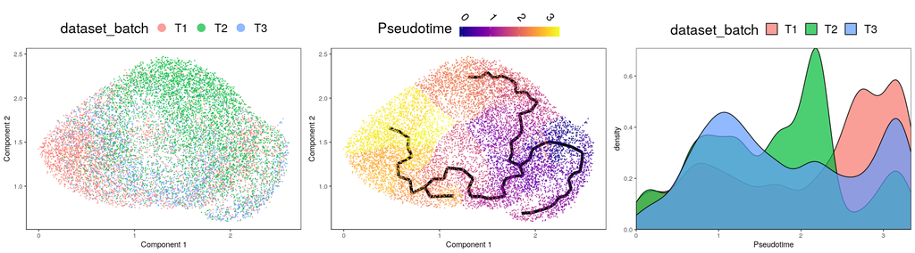

```r
p_monocle_scanorama
```

```r
tt1=ks.test(df_den$Pseudotime[df_den$dataset_batch=="T1"],df_den$Pseudotime[df_den$dataset_batch=="T3"])
tt1
```

```
##
##  Two-sample Kolmogorov-Smirnov test
##
## data:  df_den$Pseudotime[df_den$dataset_batch == "T1"] and df_den$Pseudotime[df_den$dataset_batch == "T3"]
## D = 0.22419, p-value < 2.2e-16
## alternative hypothesis: two-sided
```

```r
tt2=ks.test(df_den$Pseudotime[df_den$dataset_batch=="T1"],df_den$Pseudotime[df_den$dataset_batch=="T2"])
tt2
```

```
##
##  Two-sample Kolmogorov-Smirnov test
##
## data:  df_den$Pseudotime[df_den$dataset_batch == "T1"] and df_den$Pseudotime[df_den$dataset_batch == "T2"]
## D = 0.41335, p-value < 2.2e-16
## alternative hypothesis: two-sided
```

```r
tt3=ks.test(df_den$Pseudotime[df_den$dataset_batch=="T2"],df_den$Pseudotime[df_den$dataset_batch=="T3"])
tt3
```

```
##
##  Two-sample Kolmogorov-Smirnov test
##
## data:  df_den$Pseudotime[df_den$dataset_batch == "T2"] and df_den$Pseudotime[df_den$dataset_batch == "T3"]
## D = 0.22625, p-value < 2.2e-16
## alternative hypothesis: two-sided
```

```r
Stable5[8,2:4]=matrix(get_p_new(c(tt1$p.value,tt2$p.value,tt3$p.value)),1,3)
```

```r
p_feature_scanorama=plot_cell_clusters(cds,markers =c("FCGR3A","S100A8"),cell_size = 0.8,alpha=1)+
  scale_colour_gradient(name="",low="grey",high="red")+theme(legend.position = "right",strip.text = element_text(size=20,face="bold"))
```

```
## 'colour', which will replace the existing scale.
```

```r
p2=plot_cell_clusters(cds,markers =c("CD14","CD163"),cell_size = 0.8,alpha=1)+
  scale_colour_gradient(name="",low="grey",high="red")+theme(legend.position = "right",strip.text = element_text(size=20,face="bold"))
```

```
## 'colour', which will replace the existing scale.
```

```r
#ggsave("~/Documents/DESC_paper_prepare/DESC_paper_v3/figures/figure_supp/monocyte_scanorama_monocle3_feature.tiff",p1,width=12,height = 5,dpi=200)
#ggsave("~/Documents/DESC_paper_prepare/DESC_paper_v3/figures/figure_supp/monocyte_scanorama_add_monocle3_feature.tiff",p2,width=12,height = 5,dpi=200)
```

```r
cds_exprs <-  as.matrix(exprs(cds[c("FCGR3A","S100A8")]))[1:2,]
df0=data.frame(cbind(pseudotime=pData(cds)$Pseudotime,log1p(t(cds_exprs)/sizeFactors(cds))))
df0$BatchID=pData(cds)$dataset_batch
df0=df0[is.finite(df0$pseudotime),]
df0=df0[order(df0$pseudotime,decreasing = F),,drop=F]
df0$x=df0$pseudotime/max(df0$pseudotime)
df_pseudotime_list$scanorama=df0
```

```r
names(df_pseudotime_list)[which(names(df_pseudotime_list)=="desc")]="DESC"
names(df_pseudotime_list)[which(names(df_pseudotime_list)=="BERMUDA0.90")]="BERMUDA"
save(df_pseudotime_list,file = "df_pseudotime_list_paper_final.RData")
#load("./df_pseudotime_list_paper_final.RData")
```

# Figure 7

- top

```r
#top,right, bottom, right
p=egg::ggarrange(p_desc_2+theme(plot.margin = unit(c(0,0,2,0), "cm")),p_desc_3+theme(plot.margin = unit(c(0,2,0,0), "cm")),
                 p_cca3.0_2,p_cca3.0_3,
                 p_cca_2+theme(plot.margin = unit(c(0,0,2,0), "cm")),p_cca_3,p_mnn_2,p_mnn_3,
                 p_scvi_2+theme(plot.margin = unit(c(0,0,2,0), "cm")),p_scvi_3,p_bermuda_2,p_bermuda_3,
                 p_scanorama_2,p_scanorama_3,p_ori_2,p_ori_3,
                 ncol=4,draw=F,
                 labels = c("a","","b","","c","","d","","e","","f","","g","","h",""),
                 label.args = list(gp = grid::gpar(cex =3.5,color="black",face="bold"),just="bottom"))
                       #label.args = list(gp = grid::gpar(cex =3.5,color="black",face="bold"),y=unit(7.5,"line")))
```

```r
pp=ggdraw() +
  draw_plot(p, x=0, y=0, width=1, height = 1)+
  draw_label("DESC+monocle3",x=0.25,y=1,hjust=0.5,vjust=1,fontface = "bold",size=30)+
  draw_label("Seurat3.0+monocle3",x=0.75,y=1,hjust=0.5,vjust=1,fontface = "bold",size=30)+
  draw_label("CCA+monocle3",x=0.25,y=0.75,hjust=0.5,vjust=1,fontface = "bold",size=30)+
  draw_label("MNN+monocle3",x=0.75,y=0.75,hjust=0.5,vjust=1,fontface = "bold",size=30)+
 draw_label("scVI+monocle3",x=0.25,y=0.496,hjust=0.5,vjust=1,fontface = "bold",size=30)+
  draw_label("BERMUDA+monocle3",x=0.75,y=0.496,hjust=0.5,vjust=1,fontface = "bold",size=30)+
  draw_label("scanorama+monocle3",x=0.248,y=0.25,hjust=0.5,vjust=1,fontface = "bold",size=30)+
  draw_label("raw+monocle3",x=0.75,y=0.248,hjust=0.5,vjust=1,fontface = "bold",size=30)
```

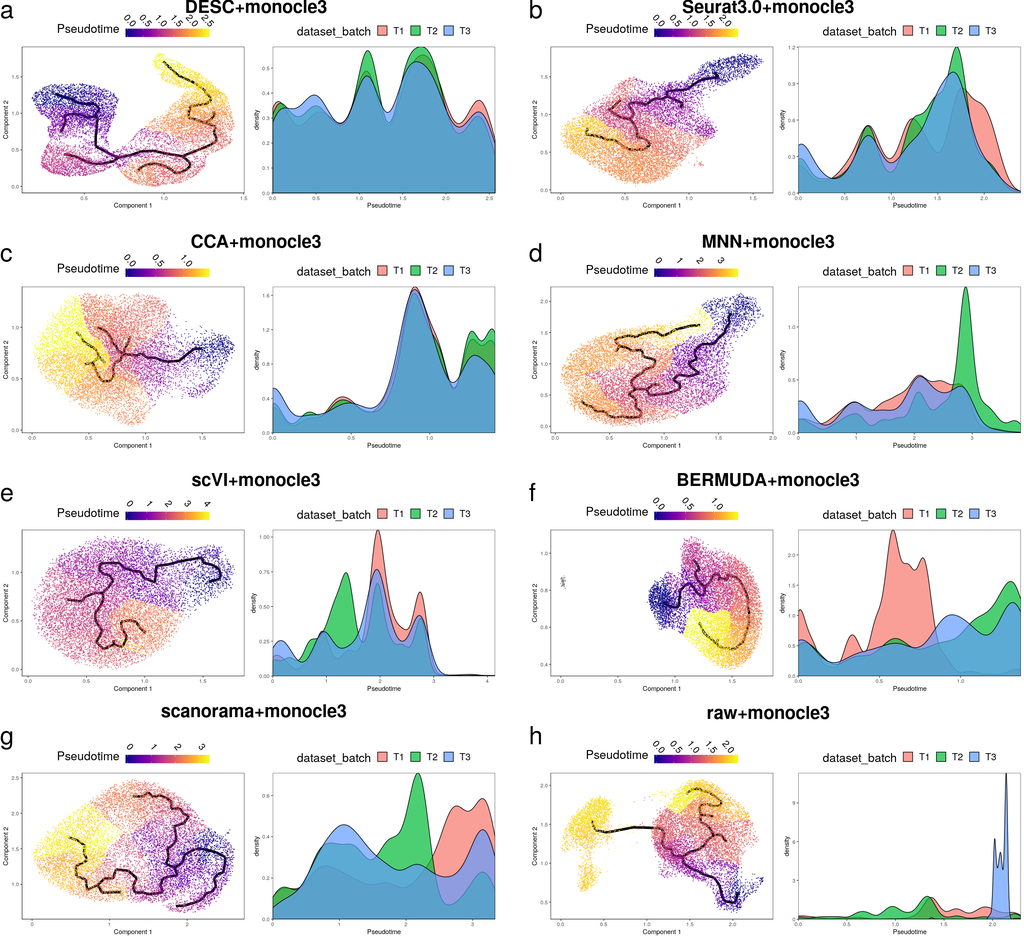

```r
#ggsave("~/Documents/DESC_paper_prepare/DESC_paper_v3/figures/figure_main/monocyte_pseudotime_batch.tiff",p,width=24,height=22,dpi=300,compression="lzw")
pp
```

-bottom

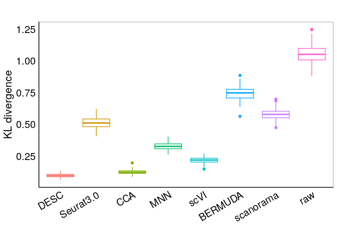

```r
data_KL0=do.call("rbind",lapply(names(KL_list),function(x){
  tmp=data.frame(value=KL_list[[x]])
  tmp$Method=x
  return(tmp)
}))
df=data_KL0
colnames(df)=c("value","Method")
df$Method=factor(df$Method,levels=c("DESC","Seurat3.0","CCA","MNN","scVI","BERMUDA0.90","scanorama","raw"),
                 labels=c("DESC","Seurat3.0","CCA","MNN","scVI","BERMUDA","scanorama","raw"))
p_KL=ggplot(df,aes(Method,value))+
   geom_boxplot(aes(color=Method))+
   xlab("")+
   ylab("KL divergence")+
   theme_self+theme(
   axis.text.x   = element_text(angle = 30,hjust=1,vjust=1),
   panel.border =element_blank(),
   axis.line = element_line())+
   ggtitle("")+theme(legend.position = "none")
p_KL
```

```r
pp2=ggdraw() +
  draw_plot(pp, x=0, y=0.2, width=1, height = 0.8)+
  draw_plot(p_KL,x=0.25, y=0, width=0.5, height = 0.2)+
  draw_label("i",x=0.25,y=0.2,hjust=0.5,vjust=1,fontface = "bold",size=35)
```

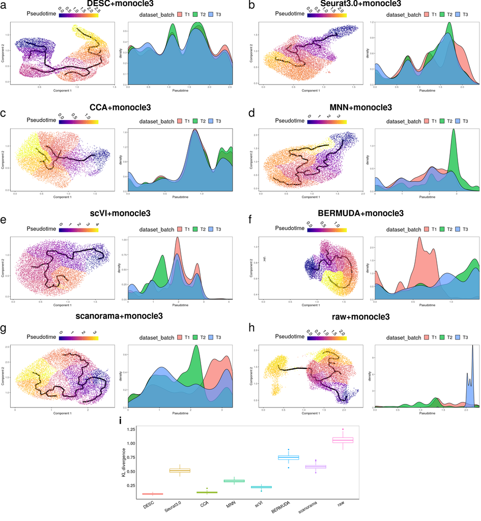

```r
#ggsave("~/Documents/DESC_paper_prepare/DESC_paper_v3/figures/figure_main/monocyte_pseudotime_batch.tiff",p,width=24,height=22,dpi=300,compression="lzw")
pp2
```

```r
## Figure 7
ggsave(file.path(fig_path,"Figure.7.tiff"),pp2,width=24,height = 26,dpi=300,compression="lzw")
ggsave(file.path(fig_path,"Figure.7.pdf"),pp2,width=24,height = 26,dpi=300)
```

# Figure 8

```r
xx=lapply(names(df_pseudotime_list),function(x){
  x1=df_pseudotime_list[[x]]
  x1$Method=x
  return(x1)
})
df_all=do.call("rbind",xx)
df_all$Method=factor(df_all$Method,names(df_pseudotime_list[c(2:length(df_pseudotime_list),1)]))
```

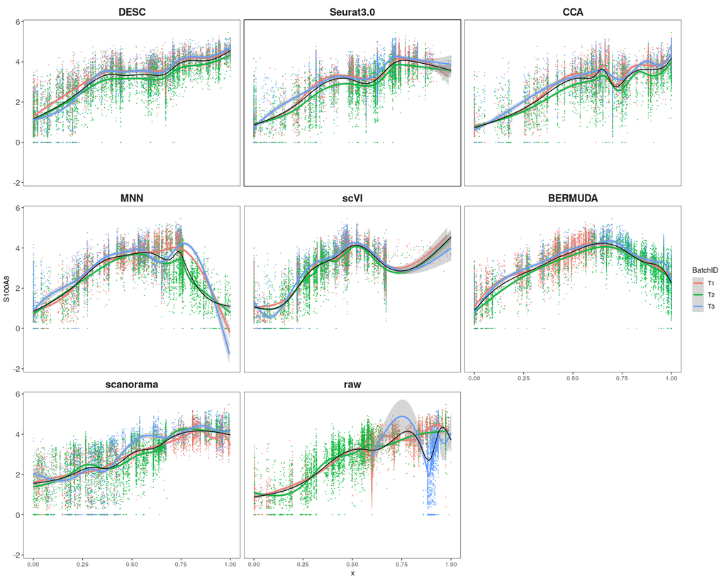

```r
ggplot(data=df_all,aes(x=x,y=S100A8))+
  geom_point(aes(color=BatchID),size=0.01)+
  geom_smooth(aes(color=BatchID),method="gam",formula = y ~ s(x, bs="cs"))+
  geom_smooth(color="black",method="gam",formula = y ~ s(x, bs="cs"),size=0.5)+
  facet_wrap(~Method,ncol=3)+
  theme(strip.background = element_blank(),
        strip.text = element_text(size=15,face="bold"),
        axis.text.y = element_text(size=12))
```

```r
#ggplot(data=df_all0,aes(x=pseudotime,y=FCGR3A))+geom_smooth(aes(color=Method))
df_all0=df_pseudotime_list[c(2:length(df_pseudotime_list),1)]
plist=lapply(names(df_all0),function(x) {
  x1=df_all0[[x]]
  p=ggplot(data=x1,aes(x=x,y=S100A8))+
    geom_point(aes(color=BatchID),size=0.01)+
    guides(color=guide_legend(override.aes = list(size=5)))+
    geom_smooth(aes(color=BatchID),method="gam",formula = y ~ s(x, bs="cs"))+
     geom_smooth(color="black",method="gam",formula = y ~ s(x, bs="cs"),size=0.5)+
    ggtitle(x)+xlab("Pseudotime")+theme(legend.position = "top",
                             plot.title = element_text(size=18,face="bold",hjust=0.5),
                             legend.text = element_text(size=15,face="bold"),
                             legend.title = element_blank())
  return(p)
  #geom_point(size=0.01,position = position_jitter(width = 0.05))+geom_smooth(method="gam",formula = y ~ s(x, bs="cs"))
})


p_legend=get_legend(plist[[1]])

p=egg::ggarrange(plots = lapply(plist,function(x) x+theme(legend.position = "none")),
                                            ncol=3,draw=F,
                 labels = c("a","b","c","d","e","f","g","h"),
                 label.args = list(gp = grid::gpar(cex =2.5,color="black",face="bold"),just="bottom"))
```

```
## adding dummy grobs
```

```r
                       #label.args = list(gp = grid::gpar(cex =3.5,color="black",face="bold"),y=unit(7.5,"line")))
```

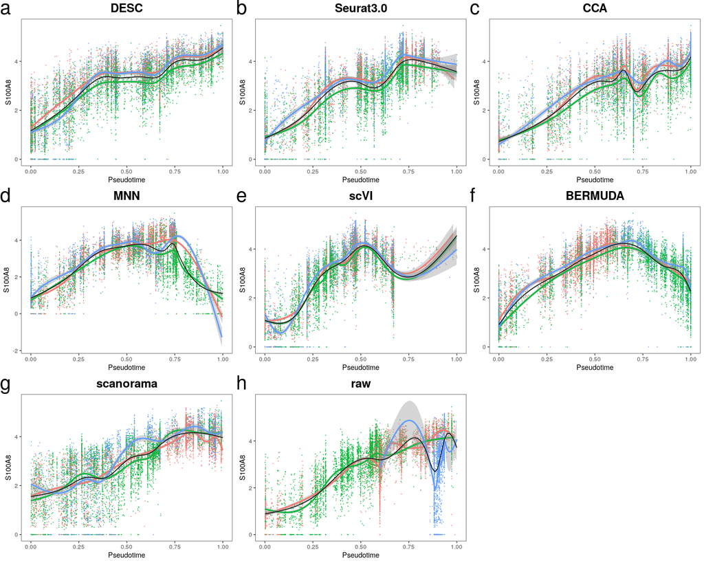

```r
p
```

```r
p_legend=get_legend(plist[[1]])
pp2=ggdraw() +
  draw_plot(p, x=0, y=0, width=1, height = 1)+
  draw_plot(plot_grid(p_legend),x=0.60, y=0, width=0.4, height = 0.4)
```

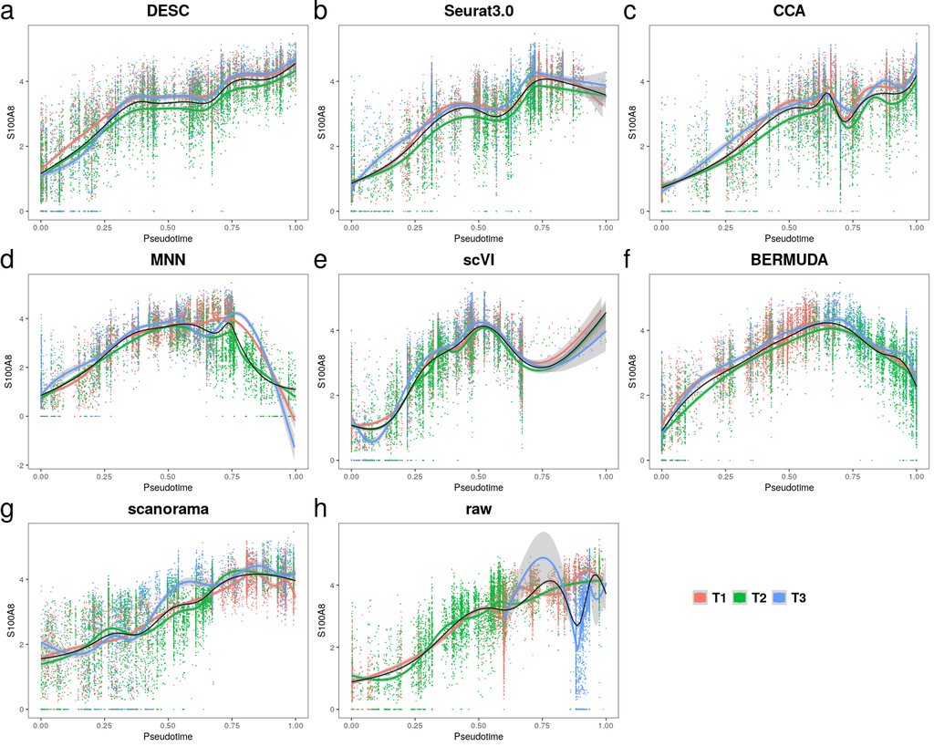

```r
pp2
```

```r
## Figure 8
ggsave(file.path(fig_path,"Figure.8.tiff"),pp2,width=15,height = 12,dpi=300,compression="lzw")
ggsave(file.path(fig_path,"Figure.8.pdf"),pp2,width=15,height = 12,dpi=300)
```

# Supplementary Figure 14

```r
df_all0=

xx0=list(p_feature_ori,
         p_feature_desc,
         p_feature_cca3.0,
         p_feature_cca,
         p_feature_mnn,
         p_feature_scvi,
         p_feature_bermuda0.90,
         p_feature_scanorama)
names(xx0)=names(df_pseudotime_list)
plist0=xx0[c(2:length(xx0),1)]

plist=lapply(names(plist0),function(x) {
  plist0[[x]]+ggtitle(x)+theme(plot.title = element_text(size=25,face="bold",color="blue",hjust=0.5),
                             legend.text = element_text(size=15,face="bold"),
                             legend.title = element_blank())
})
p=egg::ggarrange(plots = plist,ncol=2,draw=F,
                  labels = c("a","b","c","d","e","f","g","h"),
                 label.args = list(gp = grid::gpar(cex =2.5,color="black",face="bold"),just="bottom"))
```

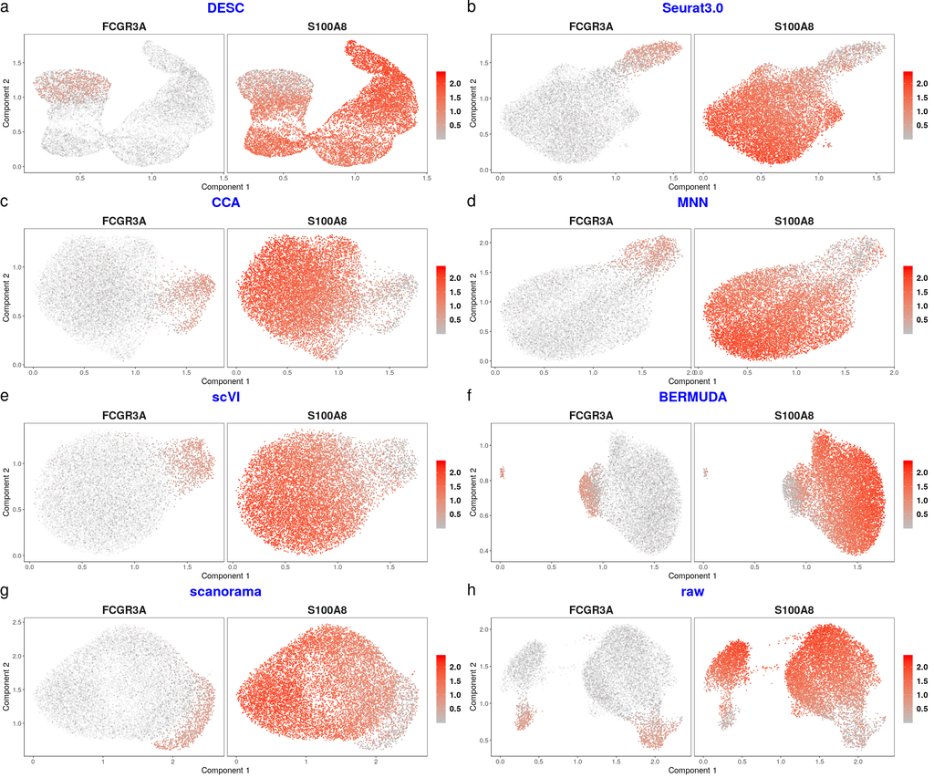

```r
## Supplementary Figure 14
ggsave(file.path(fig_path,"Figure.S14.tiff"),p,width=24,height = 20,dpi=300,compression="lzw")
ggsave(file.path(fig_path,"Figure.S14.pdf"),p,width=24,height = 20,dpi=300)
p
```

# Supplementary Figure 15

```r
#top,right, bottom, right
xx0=list(p_ori_1,p_desc_1,p_cca3.0_1,p_cca_1,p_mnn_1,p_scvi_1,p_bermuda_1,p_scanorama_1)
names(xx0)=names(df_pseudotime_list)

plist0=xx0[c(2:length(xx0),1)]
plist=lapply(names(plist0),function(x) {
  plist0[[x]]+ggtitle(x)+theme(legend.position = "top",
                             plot.title = element_text(size=18,face="bold",hjust=0.5),
                             legend.text = element_text(size=15,face="bold"),
                             legend.title = element_blank())
})

p_legend=get_legend(plist[[1]])

p=egg::ggarrange(plots = rlist::list.append(lapply(plist,function(x) x+theme(legend.position = "none")),plot_grid(p_legend)),
                                            ncol=3,draw=F,
                  labels = c("a","b","c","d","e","f","g","h",""),
                 label.args = list(gp = grid::gpar(cex =2.5,color="black",face="bold"),just="bottom"))
```

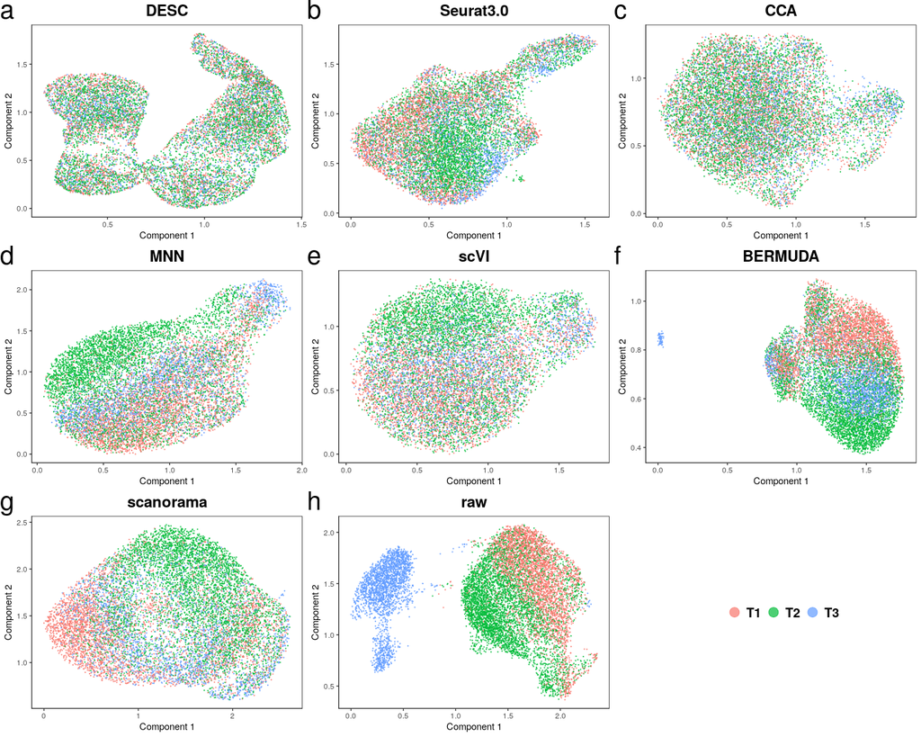

```r
p
```

```r
## Supplementary Figure 15
ggsave(file.path(fig_path,"Figure.S15.tiff"),p,width=15,height = 12,dpi=300,compression="lzw")
ggsave(file.path(fig_path,"Figure.S15.pdf"),p,width=15,height = 12,dpi=300)
```

# Supplementary Table 5

```r
#Supplementary Table 5
Stable5 %>%
  kable() %>%
  kable_styling()
```

|  | Method | T1.v.s..T2 | T1.v.s..T3 | T2.v.s..T3 |
| --- | --- | --- | --- | --- |
| raw+monocle3 | raw+monocle3 | <2.2e-16 | <2.2e-16 | <2.2e-16 |
| DESC+monocle3 | DESC+monocle3 | 4.05e-04 | 1.43e-08 | 2.17e-02 |
| Seurat3.0+monocle3 | Seurat3.0+monocle3 | <2.2e-16 | <2.2e-16 | 4.67e-09 |
| CCA+monocle3 | CCA+monocle3 | <2.2e-16 | <2.2e-16 | <2.2e-16 |
| MNN+monocle3 | MNN+monocle3 | 3.86e-14 | <2.2e-16 | <2.2e-16 |
| scVI+monocle3 | scVI+monocle3 | <2.2e-16 | <2.2e-16 | <2.2e-16 |
| BERMUDA+monocle3 | BERMUDA+monocle3 | <2.2e-16 | <2.2e-16 | <2.2e-16 |
| scanorama+monocle3 | scanorama+monocle3 | <2.2e-16 | <2.2e-16 | <2.2e-16 |